# Comprehensive Knowledge of C++(V20.04)

## template強化機能

### SFINAE

[SFINAE](https://cpprefjp.github.io/lang/cpp11/sfinae_expressions.html) (Substitution Failure Is Not An Errorの略称、スフィネェと読む)とは、 「テンプレートのパラメータ置き換えに失敗した(ill-formedになった)際に、 即時にコンパイルエラーとはせず、置き換えに失敗したテンプレートを name lookupの候補から除外する」 という言語機能である。

### コンセプト

C++17までのテンプレートには以下のような問題があった。

- SFINAEによる制約が複雑  
  テンプレートの制約を行うために、 std::enable_ifやの仕組みを使う必要があり、コードが非常に複雑で難読になりがちだった。
- エラーメッセージが不明瞭  
  テンプレートのパラメータが不適切な型だった場合に、 コンパイルエラーのメッセージが非常にわかりにくく、問題の原因を特定するのが困難だった。
- テンプレートの適用範囲が不明確  
  テンプレートの使用可能な型の範囲がドキュメントやコメントでしか表現されず、 明確な制約がコードに反映されていなかったため、コードの意図が伝わりづらい。
- 部分特殊化やオーバーロードによる冗長性  
  特定の型に対するテンプレートの処理を制限するために、 部分特殊化やテンプレートオーバーロードを行うことが多く、コードが冗長になりがちだった。

C++20から導入された「コンセプト(concepts)」は、 テンプレートパラメータを制約する機能である。 この機能を使用することで、以下のようなプログラミングでのメリットが得られる。

- テンプレートの制約を明確に定義できる  
  コンセプトを使うことで、テンプレートパラメータが満たすべき条件を宣言的に記述できるため、 コードの意図が明確にできる。
- コンパイルエラーがわかりやすくなる  
  コンセプトを使用すると、テンプレートの適用範囲外の型に対して、 より具体的でわかりやすいエラーメッセージが表示される。
- コードの可読性が向上する  
  コンセプトを利用することで、 テンプレート関数やクラスのインターフェースが明確になり、可読性が向上する。

```cpp
    //  example/term_explanation/concept_ut.cpp 12

    // SFINAEを使用したc++17スタイル
    template <typename T, typename = typename std::enable_if<std::is_arithmetic<T>::value>::type>
    T add(T a, T b)
    {
        return a + b;
    }

    //  example/term_explanation/concept_ut.cpp 24

    ASSERT_EQ(add(10, 20), 30);     // int型
    ASSERT_EQ(add(1.5, 2.5), 4.0);  // double型

    auto str1 = std::string{"Hello, "};
    auto str2 = std::string{"World!"};
    // add(str1, str2);  // これを試すとコンパイルエラー
    // concept_ut.cpp:10:3: note: candidate: ‘template<class T, class> T
    // {anonymous}::old_style::add(T, T)’
    //    10 | T add(T a, T b) {
    //       |   ^~~
    // concept_ut.cpp:10:3: note:   template argument deduction/substitution failed:
    // concept_ut.cpp:9:22: error: no type named ‘type’ in ‘struct std::enable_if<false, void>’
    //     9 | template<typename T, typename = typename
    //     std::enable_if<std::is_arithmetic<T>::value>::type>
    //       |                      ^~~~~~~~
    // エラーメッセージがわかりずらい
```

```cpp
    //  example/term_explanation/concept_ut.cpp 49

    // コンセプトを使用したC++20スタイル
    template <typename T>
    concept Arithmetic = std::is_arithmetic_v<T>;

    template <Arithmetic T>
    T add(T a, T b)
    {
        return a + b;
    }

    //  example/term_explanation/concept_ut.cpp 64

    ASSERT_EQ(add(10, 20), 30);     // int型
    ASSERT_EQ(add(1.5, 2.5), 4.0);  // double型

    auto str1 = std::string{"Hello, "};
    auto str2 = std::string{"World!"};
    // add(str1, str2);  // これを試すとコンパイルエラー
    // concept_ut.cpp:36:27: note: the expression ‘is_arithmetic_v<T> [with T =
    // std::basic_string<char, std
    // ::char_traits<char>, std::allocator<char> >]’ evaluated to ‘false’
    //    36 | concept Arithmetic = std::is_arithmetic_v<T>;
    //       |                      ~~~~~^~~~~~~~~~~~~~~~~~
    // ↑  エラーメッセージがわかりよい。テンプレートTがコンセプトfalseとなる
```

以下はテンプレートパラメータの制約にstatic_assertを使用した例である。

```cpp
    //  example/term_explanation/concept_ut.cpp 85

    // 制約のためにstatic_assertを使用したC++17スタイル
    template <typename FLOAT_0, typename FLOAT_1>
    bool is_equal(FLOAT_0 lhs, FLOAT_1 rhs) noexcept
    {
        static_assert(std::is_floating_point_v<FLOAT_0>, "FLOAT_0 shoud be float or double.");
        static_assert(std::is_same_v<FLOAT_0, FLOAT_1>, "FLOAT_0 and FLOAT_1 shoud be a same type.");

        return std::abs(lhs - rhs) <= std::numeric_limits<FLOAT_0>::epsilon();
    }
```

以上の関数テンプレートをコンセプトを使用して改善した例である。

```cpp
    //  example/term_explanation/concept_ut.cpp 113

    // 標準コンセプト std::floating_point と std::same_as を使用
    template <std::floating_point FLOAT_0, std::same_as<FLOAT_0> FLOAT_1>
    bool is_equal(FLOAT_0 lhs, FLOAT_1 rhs) noexcept
    {
        return std::abs(lhs - rhs) <= std::numeric_limits<FLOAT_0>::epsilon();
    }
```

フレキシブルに制約を記述するためにrequiresを使用したコード例を下記する。

```cpp
    //  example/term_explanation/concept_ut.cpp 138

    #if __cplusplus >= 202002L  // c++20

    // requiresを使った関数テンプレートの制約
    template <typename FLOAT_0, typename FLOAT_1>
    requires std::floating_point<FLOAT_0> && std::same_as<FLOAT_0, FLOAT_1>
    bool is_equal(FLOAT_0 lhs, FLOAT_1 rhs) noexcept
    {
        return std::abs(lhs - rhs) <= std::numeric_limits<FLOAT_0>::epsilon();
    }

    #else  // c++17
    template <typename FLOAT_0, typename FLOAT_1>
    bool is_equal(FLOAT_0 lhs, FLOAT_1 rhs) noexcept
    {
        static_assert(std::is_same_v<FLOAT_0, FLOAT_1>);
        return std::abs(lhs - rhs) <= std::numeric_limits<FLOAT_0>::epsilon();
    }
    #endif
```

### 畳み込み式

畳み式(fold expression)とは、C++17から導入された新機能であり、 可変引数テンプレートのパラメータパックに対して二項演算を累積的に行うためのものである。

畳み込み式のシンタックスの使用は下記のようなものである。

```
( pack op ... )          // (1) 単項右畳み込み
( ... op pack )          // (2) 単項左畳み込み
( pack op ... op init )  // (3) 二項右畳み込み
( init op ... op pack )  // (4) 二項左畳み込み
```

1. 単項右畳み込み

```cpp
    //  example/term_explanation/flold_expression_ut.cpp 9

    namespace cpp14_style {  // c++14までのスタイル
    template <typename T>
    constexpr bool all_true(T arg)
    {
        return arg;
    }
    template <typename T, typename... Args>
    constexpr bool all_true(T arg, Args... args)
    {
        return arg && all_true(args...);
    }
    }  // namespace cpp14_style

    namespace cpp17_style {  // 畳み込み式を使用したスタイル
    template <typename... Ts>
    constexpr bool all_true(Ts... args)
    {
        return (args && ...);  // 単項右畳み込み
    }
    }  // namespace cpp17_style

    static_assert(cpp14_style::all_true(true, true, true));
    static_assert(cpp17_style::all_true(true, true, true));
```

2. 単項左畳み込み

```cpp
    //  example/term_explanation/flold_expression_ut.cpp 36
    namespace cpp14_style {  // c++14までのスタイル
    template <typename T>
    constexpr bool any_true(T arg)
    {
        return arg;
    }
    template <typename T, typename... Args>
    constexpr bool any_true(T arg, Args... args)
    {
        return arg || any_true(args...);
    }
    }  // namespace cpp14_style

    namespace cpp17_style {  // 畳み込み式を使用したスタイル
    template <typename... Ts>
    constexpr bool any_true(Ts... args)
    {
        return (... || args);  // 単項左畳み込み
    }
    }  // namespace cpp17_style
    static_assert(cpp14_style::any_true(false, false, true));
    static_assert(cpp17_style::any_true(false, false, true));
```

3. 二項右畳み込み

```cpp
    //  example/term_explanation/flold_expression_ut.cpp 61

    namespace cpp14_style {  // c++14までのスタイル
    template <typename T>
    constexpr int sum(T arg)
    {
        return arg;
    }
    template <typename T, typename... Args>
    constexpr int sum(T arg, Args... args)
    {
        return arg + sum(args...);
    }

    }  // namespace cpp14_style

    namespace cpp17_style {  // 畳み込み式を使用したスタイル
    template <typename... Ts>
    constexpr int sum(Ts... args)
    {
        return (args + ... + 0);  // 二項右畳み込み (初期値: 0)
    }
    }  // namespace cpp17_style

    static_assert(cpp14_style::sum(1, 2, 3));
    static_assert(cpp17_style::sum(1, 2, 3));
```

4. 二項左畳み込み

```cpp
    //  example/term_explanation/flold_expression_ut.cpp 89

    namespace cpp14_style {  // c++14までのスタイル
    template <typename T>
    constexpr int product(T arg)
    {
        return arg;
    }
    template <typename T, typename... Args>
    constexpr int product(T arg, Args... args)
    {
        return arg * product(args...);
    }
    }  // namespace cpp14_style

    namespace cpp17_style {  // 畳み込み式を使用したスタイル
    template <typename... Ts>
    constexpr int product(Ts... args)
    {
        return (1 * ... * args);  // 二項左畳み込み (初期値: 1)
    }
    }  // namespace cpp17_style

    static_assert(cpp14_style::product(2, 3, 4));
    static_assert(cpp17_style::product(2, 3, 4));
```

上記したような単純な例では、畳み込み式の効果はわかりづらいため、 もっと複雑なで読解が困難な再帰構造を持ったコードを以下に示す。

```cpp
    //  example/term_explanation/flold_expression_ut.cpp 117
    template <typename T, typename U, typename... Us>
    struct is_same_some_of {
        static constexpr bool value{std::is_same_v<T, U> ? true : is_same_some_of<T, Us...>::value};
    };

    template <typename T, typename U>
    struct is_same_some_of<T, U> {
        static constexpr bool value{std::is_same_v<T, U>};
    };
```

```cpp
    //  example/term_explanation/flold_expression_ut.cpp 128

    static_assert(is_same_some_of<int, int, double, char>::value);
    static_assert(!is_same_some_of<int, double, char>::value);
    static_assert(is_same_some_of<std::string, std::string, int>::value);
```

畳み込み式を使うことで、この問題をある程度緩和したコードを下記する。

```cpp
    //  example/term_explanation/flold_expression_ut.cpp 140
    template <typename T, typename U, typename... Us>
    struct is_same_some_of {
        static constexpr bool value = (std::is_same_v<T, U> || ... || std::is_same_v<T, Us>);
    };
```

```cpp
    //  example/term_explanation/flold_expression_ut.cpp 146

    static_assert(is_same_some_of<int, int, double, char>::value);
    static_assert(!is_same_some_of<int, double, char>::value);
    static_assert(is_same_some_of<std::string, std::string, int>::value);
```

### ジェネリックラムダ

ジェネリックラムダとは、C++11のラムダ式のパラメータの型にautoを指定できるようにした機能で、 C++14で導入された。

この機能により関数の中で関数テンプレートと同等のものが定義できるようになった。

ジェネリックラムダで定義されたクロージャは、通常のラムダと同様にオブジェクトであるため、 下記のように使用することもできる便利な記法である。

```cpp
    //  example/term_explanation/generic_lambda_ut.cpp 4

    template <typename PUTTO>
    void f(PUTTO&& p)
    {
        p(1);
        p(2.71);
        p("str");
    }

    TEST(Template, generic_lambda)
    {
        std::ostringstream oss;

        f([&oss](auto const& elem) { oss << elem << std::endl; });

        ASSERT_EQ("1\n2.71\nstr\n", oss.str());
    }
```

なお、上記のジェネリックラムダは下記クラスのインスタンスの動きと同じである。

```cpp
    //  example/term_explanation/generic_lambda_ut.cpp 23

    class Closure {
    public:
        Closure(std::ostream& os) : os_(os) {}

        template <typename T>
        void operator()(T&& t)
        {
            os_ << t << std::endl;
        }

    private:
        std::ostream& os_;
    };

    TEST(Template, generic_lambda_like)
    {
        std::ostringstream oss;

        Closure closure(oss);
        f(closure);

        ASSERT_EQ("1\n2.71\nstr\n", oss.str());
    }
```

### クラステンプレートのテンプレート引数の型推論

C++17から、 「コンストラクタに渡される値によって、クラステンプレートのテンプレート引数を推論する」 機能が導入された。

この機能がないC++14までは以下のように記述する必要があった。

```cpp
    //  example/term_explanation/template_ut.cpp 13

    auto a = std::vector<int>{1, 2, 3};

    static_assert(std::is_same_v<decltype(a), std::vector<int>>);
```

これに対して、この機能により、以下のようにシンプルに記述できるようになった。

```cpp
    //  example/term_explanation/template_ut.cpp 24

    auto a = std::vector{1, 2, 3};

    static_assert(std::is_same_v<decltype(a), std::vector<int>>);  // テンプレート引数がintと推論
```

### テンプレートの型推論ガイド

テンプレートの型推論ガイドは、C++17で導入された機能である。この機能により、 クラステンプレートのインスタンス化時にテンプレート引数を明示的に指定せず、 引数から自動的に型を推論できるようになる。型推論ガイドを使用することで、 コードの可読性と簡潔性が向上する。

型推論ガイドがない場合、クラステンプレートのテンプレート引数の型推論は限定的であり、 明示的にテンプレート引数を指定する必要がある場合が多い。 一方、型推論ガイドを使用することで、 コンストラクタの引数からテンプレート引数を自動的に決定することが可能になる。

```cpp
    //  example/term_explanation/deduction_guide_ut.cpp 8

    template <typename T>  // Tが整数型の場合、暗黙の型変換を許可
    struct S {
        // T が整数型でない場合に有効なコンストラクタ
        template <typename U = T, std::enable_if_t<!std::is_integral_v<U>>* = nullptr>
        explicit S(U x) : value{x}
        {
        }

        // T が整数型の場合に有効な非explicitコンストラクタ
        template <typename U = T, std::enable_if_t<std::is_integral_v<U>>* = nullptr>
        S(U x) : value{x}
        {
        }

        T value;
    };
```

上記のクラステンプレートは、ガイドがない場合、 以下に示すように型推論によりテンプレート引数を決定することができない。

```cpp
    //  example/term_explanation/deduction_guide_ut.cpp 31

    S<int>    s1{42};   // 明示的にテンプレート引数を指定
    S<double> s2{1.0};  // 明示的にテンプレート引数を指定

    // テンプレート引数の推論ができず、下記はコンパイルできない
    // S       s1{42};   // 明示的にテンプレート引数を指定
    // S       s2{1.0};  // 明示的にテンプレート引数を指定
```

以上に示したクラステンプレートに以下の型推論ガイドを追加することにより、 テンプレート引数を型推論できるようになる。

```cpp
    //  example/term_explanation/deduction_guide_ut.cpp 44

    template <typename T>
    S(T) -> S<T>;
```

```cpp
    //  example/term_explanation/deduction_guide_ut.cpp 52

    S s1{42};   // 推論ガイドの効果
    S s2{1.0};  // 推論ガイドの効果
    S s3 = 42;  // S<int>のコンストラクタがintであるため、暗黙の型変換が可能
    // S    s4 = 1.0;  // S<double>のコンストラクタがexplicitであるため
```

### 変数テンプレート

変数テンプレートとは、下記のコード示したような機能である。

```cpp
    //  example/term_explanation/template_ut.cpp 32

    template <typename T>
    struct is_void {
        static constexpr bool value = false;
    };

    template <>
    struct is_void<void> {
        static constexpr bool value = true;
    };

    static_assert(is_void<void>::value);
    static_assert(!is_void<int>::value);
    // 以上はC++14以前のスタイル

    // 以下はC++17から導入された
    template <typename T>
    constexpr bool is_void_v = is_void<T>::value;

    static_assert(is_void_v<void>);
    static_assert(!is_void_v<int>);
```

なお、変数テンプレートはconstexprと定義されるが、 「定数テンプレート」ではなく変数テンプレートである。

### エイリアステンプレート

エイリアステンプレート(alias templates)とはC++11から導入され、 下記のコード例で示したようにテンプレートによって型の別名を定義する機能である。

```cpp
    //  example/term_explanation/template_ut.cpp 56

    using IntVector = std::vector<int>;  // std::vector<int> のエイリアスを定義

    template <typename T>  //エイリアステンプレートを定義
    using Vec = std::vector<T>;

    static_assert(std::is_same_v<IntVector, Vec<int>>);  // Vec<int> == std::vector<int>
```

### constexpr if文

C++17で導入された[constexpr if文](https://cpprefjp.github.io/lang/cpp17/if_constexpr.html)とは、 文を条件付きコンパイルすることができるようにするための制御構文である。

まずは、この構文を使用しない例を示す。

```cpp
    //  example/term_explanation/constexpr_if_ut.cpp 9

    // 配列のサイズ
    template <typename T>
    auto Length(T const&) -> std::enable_if_t<std::is_array_v<T>, size_t>
    {
        return std::extent_v<T>;
    }

    // コンテナのサイズ
    template <typename T>
    auto Length(T const& t) -> decltype(t.size())
    {
        return t.size();
    }

    // その他のサイズ
    size_t Length(...) { return 0; }
```

```cpp
    //  example/term_explanation/constexpr_if_ut.cpp 31

    uint32_t a[5];
    auto     v = std::vector{0, 1, 2};
    struct SizeTest {
    } t;

    ASSERT_EQ(5, Length(a));
    ASSERT_EQ(3, Length(v));
    ASSERT_EQ(0, Length(t));

    // C++17で、Lengthと同様の機能の関数テンプレートがSTLに追加された
    ASSERT_EQ(std::size(a), Length(a));
    ASSERT_EQ(std::size(v), Length(v));
```

このような場合、SFINAEによるオーバーロードが必須であったが、 この文を使用することで、下記のようにオーバーロードを使用せずに記述できるため、 条件分岐の可読性の向上が見込める。

```cpp
    //  example/term_explanation/constexpr_if_ut.cpp 52

    struct helper {
        template <typename T>
        auto operator()(T const& t) -> decltype(t.size());
    };

    template <typename T>
    size_t Length(T const& t)
    {
        if constexpr (std::is_array_v<T>) {  // Tが配列の場合
            // Tが配列でない場合、他の条件のブロックはコンパイル対象外
            return std::extent_v<T>;
        }
        else if constexpr (std::is_invocable_v<helper, T>) {  // T::Lengthが呼び出せる場合
            // T::Lengthが呼び出せない場合、他の条件のブロックはコンパイル対象外
            return t.size();
        }
        else {  // それ以外
            // Tが配列でなく且つ、T::Lengthが呼び出ない場合、他の条件のブロックはコンパイル対象外
            return 0;
        }
    }
```

この構文はパラメータパックの展開においても有用な場合がある。

```cpp
    //  example/term_explanation/constexpr_if_ut.cpp 93

    // テンプレートパラメータで与えられた型のsizeofの値が最も大きな値を返す。
    template <typename HEAD>
    constexpr size_t MaxSizeof()
    {
        return sizeof(HEAD);
    }

    template <typename HEAD, typename T, typename... TAILS>
    constexpr size_t MaxSizeof()
    {
        return std::max(sizeof(HEAD), MaxSizeof<T, TAILS...>());
    }
```

```cpp
    //  example/term_explanation/constexpr_if_ut.cpp 111

    static_assert(4 == (MaxSizeof<int8_t, int16_t, int32_t>()));
    static_assert(4 == (MaxSizeof<int32_t, int16_t, int8_t>()));
    static_assert(sizeof(std::string) == MaxSizeof<int32_t, int16_t, int8_t, std::string>());
```

C++14までの構文を使用する場合、 上記のようなオーバーロードとリカーシブコールの組み合わせが必要であったが、 constexpr ifを使用することで、やや単純に記述できる。

```cpp
    //  example/term_explanation/constexpr_if_ut.cpp 123

    // テンプレートパラメータで与えられた型のsizeofの値が最も大きな値を返す。
    template <typename HEAD, typename... TAILS>
    constexpr size_t MaxSizeof()
    {
        if constexpr (sizeof...(TAILS) == 0) {  // TAILSが存在しない場合
            return sizeof(HEAD);
        }
        else {
            return std::max(sizeof(HEAD), MaxSizeof<TAILS...>());
        }
    }
```

### autoパラメータによる関数テンプレートの簡易定義

この機能は、C++20から導入された。 下記のコードで示すように簡易的に関数テンプレートを定義するための機能である。

```cpp
    //  example/term_explanation/decltype_ut.cpp 182

    #if __cplusplus >= 202002L  // c++20
    auto add(auto lhs, auto rhs) {
        return lhs + rhs;
    }

    #else  // c++17
    template <typename T, typename U>
    auto add(T lhs, U rhs)
    {
        return lhs + rhs;
    }
    #endif
```

```cpp
    //  example/term_explanation/decltype_ut.cpp 201

    ASSERT_EQ(add(1, 2), 3);

    ASSERT_DOUBLE_EQ(add(1.5, 2.5), 4.0);

    using namespace std::literals::string_literals;

    ASSERT_EQ(add("hello"s, "world"s), "helloworld"s);
```

## 型推論

### AAAスタイル

このドキュメントでのAAAとは、単体テストのパターンarrange-act-assertではなく、 almost always autoを指し、 AAAスタイルとは、「可能な場合、型を左辺に明示して変数を宣言する代わりに、autoを使用する」 というコーディングスタイルである。 この用語は、Andrei Alexandrescuによって造られ、Herb Sutterによって広く推奨されている。

特定の型を明示して使用する必要がない場合、下記のように書く。

```cpp
    //  example/term_explanation/aaa.cpp 11

    auto i  = 1;
    auto ui = 1U;
    auto d  = 1.0;
    auto s  = "str";
    auto v  = {0, 1, 2};

    for (auto i : v) {
        // 何らかの処理
    }

    auto add = [](auto lhs, auto rhs) {  // -> return_typeのような記述は不要
        return lhs + rhs;                // addの型もautoで良い
    };

    // 上記変数の型の確認
    static_assert(std::is_same_v<decltype(i), int>);
    static_assert(std::is_same_v<decltype(ui), unsigned int>);
    static_assert(std::is_same_v<decltype(d), double>);
    static_assert(std::is_same_v<decltype(s), char const*>);
    static_assert(std::is_same_v<decltype(v), std::initializer_list<int>>);

    char s2[] = "str";  // 配列の宣言には、AAAは使えない
    static_assert(std::is_same_v<decltype(s2), char[4]>);

    int* p0 = nullptr;  // 初期値がnullptrであるポインタの初期化には、AAAは使うべきではない
    auto p1 = static_cast<int*>(nullptr);  // NG
    auto p2 = p0;                          // OK
    auto p3 = nullptr;                     // NG 通常、想定通りにならない
    static_assert(std::is_same_v<decltype(p3), std::nullptr_t>);
```

特定の型を明示して使用する必要がある場合、下記のように書く。

```cpp
    //  example/term_explanation/aaa.cpp 51

    auto b  = new char[10]{0};
    auto v  = std::vector<int>{0, 1, 2};
    auto s  = std::string{"str"};
    auto sv = std::string_view{"str"};

    static_assert(std::is_same_v<decltype(b), char*>);
    static_assert(std::is_same_v<decltype(v), std::vector<int>>);
    static_assert(std::is_same_v<decltype(s), std::string>);
    static_assert(std::is_same_v<decltype(sv), std::string_view>);

    // 大量のstd::stringオブジェクトを定義する場合
    using std::literals::string_literals::operator""s;

    auto s_0 = "222"s;  // OK
    // ...
    auto s_N = "222"s;  // OK

    static_assert(std::is_same_v<decltype(s_0), std::string>);
    static_assert(std::is_same_v<decltype(s_N), std::string>);

    // 大量のstd::string_viewオブジェクトを定義する場合
    using std::literals::string_view_literals::operator""sv;

    auto sv_0 = "222"sv;  // OK
    // ...
    auto sv_N = "222"sv;  // OK

    static_assert(std::is_same_v<decltype(sv_0), std::string_view>);
    static_assert(std::is_same_v<decltype(sv_N), std::string_view>);

    std::mutex mtx;  // std::mutexはmove出来ないので、AAAスタイル不可
    auto       lock = std::lock_guard{mtx};

    static_assert(std::is_same_v<decltype(lock), std::lock_guard<std::mutex>>);
```

関数の戻り値を受け取る変数を宣言する場合、下記のように書く。

```cpp
    //  example/term_explanation/aaa.cpp 94

    auto v = std::vector<int>{0, 1, 2};

    // AAAを使わない例
    std::vector<int>::size_type t0{v.size()};      // 正確に書くとこうなる
    std::vector<int>::iterator  itr0 = v.begin();  // 正確に書くとこうなる

    std::unique_ptr<int> p0 = std::make_unique<int>(3);

    // 上記をAAAにした例
    auto t1   = v.size();   // size()の戻りは算術型であると推測できる
    auto itr1 = v.begin();  // begin()の戻りはイテレータであると推測できる

    auto p1 = std::make_unique<int>(3);  // make_uniqueの戻りはstd::unique_ptrであると推測できる
```

ただし、関数の戻り値型が容易に推測しがたい下記のような場合、 型を明示しないAAAスタイルは使うべきではない。

```cpp
    //  example/term_explanation/aaa.cpp 121

    extern std::map<std::string, int> gen_map();

    // 上記のような複雑な型を戻す関数の場合、AAAを使うと可読性が落ちる
    auto map0 = gen_map();

    for (auto [str, i] : gen_map()) {
        // 何らかの処理
    }

    // 上記のような複雑な型を戻す関数の場合、AAAを使うと可読性が落ちるため、AAAにしない
    std::map<std::string, int> map1 = gen_map();  // 型がコメントとして役に立つ

    for (std::pair<std::string, int> str_i : gen_map()) {
        // 何らかの処理
    }

    // 型を明示したAAAスタイルでも良い
    auto map2 = std::map<std::string, int>{gen_map()};  // 型がコメントとして役に立つ
```

インライン関数や関数テンプレートの宣言は、下記のように書く。

```cpp
    //  example/term_explanation/aaa.cpp 148

    template <typename F, typename T>
    auto apply_0(F&& f, T value)
    {
        return f(value);
    }
```

ただし、インライン関数や関数テンプレートが複雑な下記のような場合、 AAAスタイルは出来る限り避けるべきである。

```cpp
    //  example/term_explanation/aaa.cpp 156

    template <typename F, typename T>
    auto apply_1(F&& f, T value) -> decltype(f(std::declval<T>()))  // autoを使用しているが、AAAではない
    {
        auto cond  = false;
        auto param = value;

        // 複雑な処理

        if (cond) {
            return f(param);
        }
        else {
            return f(value);
        }
    }
```

このスタイルには下記のような狙いがある。

- コードの安全性の向上  
  autoで宣言された変数は未初期化にすることができないため、未初期化変数によるバグを防げる。 また、下記のように縮小型変換(下記では、unsignedからsignedの変換)を防ぐこともできる。

```cpp
    //  example/term_explanation/aaa.cpp 183

    auto v = std::vector<int>{0, 1, 2};

    int t0 = v.size();  // 縮小型変換されるため、バグが発生する可能性がある
    // int t1{v.size()};   縮小型変換のため、コンパイルエラー
    auto t2 = v.size();  // t2は正確な型
```

- コードの可読性の向上  
  冗長なコードを排除することで、可読性の向上が見込める。
- コードの保守性の向上  
  「変数宣言時での左辺と右辺を同一の型にする」非AAAスタイルは [DRYの原則](https://ja.wikipedia.org/wiki/Don%27t_repeat_yourself#:~:text=Don't%20repeat%20yourself%EF%BC%88DRY,%E3%81%A7%E3%81%AA%E3%81%84%E3%81%93%E3%81%A8%E3%82%92%E5%BC%B7%E8%AA%BF%E3%81%99%E3%82%8B%E3%80%82) に反するが、この観点において、AAAスタイルはDRYの原則に沿うため、 コード修正時に型の変更があった場合でも、それに付随したコード修正を最小限に留められる。

AAAスタイルでは、以下のような場合に注意が必要である。

- 関数の戻り値をautoで宣言された変数で受ける場合  
  上記で述べた通り、AAAの過剰な仕様は、可読性を下げてしまう。
- autoで推論された型が直感に反する場合  
  下記のような型推論は、直感に反する場合があるため、autoの使い方に対する習熟が必要である。

```cpp
    //  example/term_explanation/aaa.cpp 197

    auto str0 = "str";
    static_assert(std::is_same_v<char const*, decltype(str0)>);  // str0はchar[4]ではない

    // char[]が必要ならば、AAAを使わずに下記のように書く
    char str1[] = "str";
    static_assert(std::is_same_v<char[4], decltype(str1)>);

    // &が必要になるパターン
    class X {
    public:
        explicit X(int32_t a) : a_{a} {}
        int32_t& Get() { return a_; }

    private:
        int32_t a_;
    };

    X x{3};

    auto a0 = x.Get();
    ASSERT_EQ(3, a0);

    a0 = 4;
    ASSERT_EQ(4, a0);
    ASSERT_EQ(3, x.Get());  // a0はリファレンスではないため、このような結果になる

    // X::a_のリファレンスが必要ならば、下記のように書く
    auto& a1 = x.Get();
    a1       = 4;
    ASSERT_EQ(4, a1);
    ASSERT_EQ(4, x.Get());  // a1はリファレンスであるため、このような結果になる

    // constが必要になるパターン
    class Y {
    public:
        std::string&       Name() { return name_; }
        std::string const& Name() const { return name_; }

    private:
        std::string name_{"str"};
    };

    auto const y = Y{};

    auto        name0 = y.Name();  // std::stringがコピーされる
    auto&       name1 = y.Name();  // name1はconstに見えない
    auto const& name2 = y.Name();  // このように書くべき

    static_assert(std::is_same_v<std::string, decltype(name0)>);
    static_assert(std::is_same_v<std::string const&, decltype(name1)>);
    static_assert(std::is_same_v<std::string const&, decltype(name2)>);

    // 範囲for文でのauto const&
    auto const v = std::vector<std::string>{"0", "1", "2"};

    for (auto s : v) {  // sはコピー生成される
        static_assert(std::is_same_v<std::string, decltype(s)>);
    }

    for (auto& s : v) {  // sはconstに見えない
        static_assert(std::is_same_v<std::string const&, decltype(s)>);
    }

    for (auto const& s : v) {  // このように書くべき
        static_assert(std::is_same_v<std::string const&, decltype(s)>);
    }
```

### decltype

decltypeはオペランドにexpressionを取り、その型を算出する機能である。 下記のコードにあるようなautoの機能との微妙な差に気を付ける必要がある。

```cpp
    //  example/term_explanation/decltype_ut.cpp 13

    int32_t  x{3};
    int32_t& r{x};

    auto        a = r;  // aの型はint32_t
    decltype(r) b = r;  // bの型はint32_t&

    // std::is_sameはオペランドの型が同じか否かを返すメタ関数
    static_assert(std::is_same_v<decltype(a), int>);
    static_assert(std::is_same_v<decltype(b), int&>);
```

decltypeは、テンプレートプログラミングに多用されるが、 クロージャ型(「ラムダ式」参照) のような記述不可能な型をオブジェクトから算出できるため、 下記例のような場合にも有用である。

```cpp
    //  example/term_explanation/decltype_ut.cpp 28

    //  本来ならばA::dataは、
    //      * A::Aでメモリ割り当て
    //      * A::~Aでメモリ解放
    //  すべきだが、何らかの理由でそれが出来ないとする
    struct A {
        size_t   len;
        uint8_t* data;
    };

    void do_something(size_t len)
    {
        auto deallocate = [](A* p) {
            delete[](p->data);
            delete p;
        };

        auto a_ptr = std::unique_ptr<A, decltype(deallocate)>{new A, deallocate};

        a_ptr->len  = len;
        a_ptr->data = new uint8_t[10];

        ...
        // do something for a_ptr
        ...

        // a_ptrによるメモリの自動解放
    }
```

### decltype(auto)

decltype(auto)はC++14から導入されたdecltypeの類似機能である。

auto、decltype、decltype(auto)では、以下に示す通りリファレンスの扱いが異なることに注意する必要がある。

```cpp
    //  example/term_explanation/decltype_ut.cpp 63

    int32_t  x{3};
    int32_t& r{x};

    auto           a = r;  // aの型はint32_t
    decltype(r)    b = r;  // bの型はint32_t&
    decltype(auto) c = r;  // cの型はint32_t&   C++14からサポート
                           // decltype(auto)は、decltypeに右辺の式を与えるための構文

    // std::is_sameはオペランドの型が同じか否かを返すメタ関数
    static_assert(std::is_same_v<decltype(a), int>);
    static_assert(std::is_same_v<decltype(b), int&>);
    static_assert(std::is_same_v<decltype(c), int&>);
```

### 戻り値型を後置する関数宣言

関数の戻り値型後置構文は戻り値型をプレースホルダ(auto)にして、 実際の型を->で示して型推論させるシンタックスを指す。実際には関数テンプレートで使用されることが多い。 コード例を以下に示す。

```cpp
    //  example/term_explanation/decltype_ut.cpp 82

    template <typename T, typename U>
    auto add(T a, U b) -> decltype(a + b)
    {
        return a + b;
    }

    static_assert(std::is_same_v<decltype(add(1, 2)), int>);  // addの戻り値型はintに型推論
    static_assert(std::is_same_v<decltype(add(1u, 2u)), uint32_t>);  // addの戻り値型はintに型推論
    static_assert(std::is_same_v<decltype(add(std::string{"str"}, "2")),
                                 std::string>);  // addの戻り値型はstd::stringに型推論
```

この構文をC++11から導入された理由は以下のコードを見れば明らかだろう。

```cpp
    //  example/term_explanation/decltype_ut.cpp 97

    template <typename T, typename U>  // 戻り値型を後置する関数宣言
    decltype(std::declval<T>() + std::declval<T>()) add(T a, U b)
    {
        return a + b;
    }

    static_assert(std::is_same_v<decltype(add(1, 2)), int>);  // addの戻り値型はintに型推論
    static_assert(std::is_same_v<decltype(add(1u, 2u)), uint32_t>);  // addの戻り値型はintに型推論
    static_assert(std::is_same_v<decltype(add(std::string{"str"}, "2")),
                                 std::string>);  // addの戻り値型はstd::stringに型推論
```

### 関数の戻り値型auto

C++14から導入された機能で、関数の戻り値の型をautoキーワードで宣言することで、 コンパイラがreturn文から自動的に型を推論してくれる機能である。 これにより、複雑な型の戻り値を持つ関数でも、より簡潔に記述できるようになる (「autoパラメータによる関数テンプレートの簡易定義」を参照)。

```cpp
    //  example/term_explanation/decltype_ut.cpp 114

    // 戻り値型autoが使えないと下記のような宣言が必要
    // std::vector<std::string> split(std::string_view str, char delimiter)
    auto split(std::string_view str, char delimiter)
    {
        std::vector<std::string> result;
        std::string              token;

        for (char ch : str) {
            if (ch == delimiter) {
                if (!token.empty()) {
                    result.emplace_back(std::move(token));
                }
            }
            else {
                token += ch;
            }
        }

        if (!token.empty()) {
            result.emplace_back(std::move(token));
        }

        return result;
    }
```

```cpp
    //  example/term_explanation/decltype_ut.cpp 144

    auto result = split("hello,world", ',');

    ASSERT_EQ(result.size(), 2);
    ASSERT_EQ(result[0], "hello");
    ASSERT_EQ(result[1], "world");
```

### 後置戻り値型auto

C++14から導入された関数の戻り値型autoと似た、 関数の戻り値の型を関数本体の後に-> autoと書くことでができる機能である。 autoプレースホルダーとし、そのプレースホルダーを修飾することで、戻り値型の推論を補助できる。

```cpp
    //  example/term_explanation/decltype_ut.cpp 154

    int16_t gvalue = 1;

    auto getValue(int16_t a) -> auto& { return gvalue += a; }
```

```cpp
    //  example/term_explanation/decltype_ut.cpp 163

    auto           ret1 = getValue(10);
    decltype(auto) ret2 = getValue(0);

    ASSERT_EQ(ret1, 11);
    ASSERT_EQ(ret2, 11);

    ASSERT_EQ(gvalue, 11);
    ret1 += 1;
    ASSERT_EQ(gvalue, 11);

    ret2 += 1;
    ASSERT_EQ(gvalue, 12);
```

## explicit

explicitは、コンストラクタに対して付与することで、 コンストラクタによる暗黙の型変換を禁止するためのキーワードである。 暗黙の型変換とは、ある型の値を別の型の値に自動的に変換する言語機能を指す。 explicitキーワードを付けることで、意図しない型変換を防ぎ、コードの堅牢性を高めることがでできる。

この節で説明するexplicitの機能は下記のような項目に渡って説明を行う。

- 暗黙の型変換
- 暗黙の型変換抑止
- explicit type operator()
- explicit(COND)

### 暗黙の型変換

この節で扱う暗黙の型変換とは、 以下に示したような「非explicitなコンストラクタを持つクラス」による暗黙の型変換を指し、 汎整数型昇格や算術変換等を指さない。

```cpp
    //  example/term_explanation/implicit_conversion_ut.cpp 8

    class Person {
    public:
        Person(char const* name, uint32_t age = 0) : name_{name}, age_{age} {}
        Person(Person const&)            = default;
        Person& operator=(Person const&) = default;

        std::string const& GetName() const noexcept { return name_; }
        uint32_t           GetAge() const noexcept { return age_; }

    private:
        std::string name_;  // コピーをするため非const
        uint32_t    age_;
    };

    #if __cplusplus <= 201703L  // c++17
    bool operator==(Person const& lhs, Person const& rhs) noexcept
    {
        return std::tuple(lhs.GetName(), lhs.GetAge()) == std::tuple(rhs.GetName(), rhs.GetAge());
    }

    #else  // c++20
    auto operator<=>(Person const& lhs, Person const& rhs) noexcept
    {
        return std::tuple(lhs.GetName(), lhs.GetAge()) <=> std::tuple(rhs.GetName(), rhs.GetAge());
    }

    // <=>から自動的に==が生成されないため、明示的に定義する必要がある
    bool operator==(Person const& lhs, Person const& rhs) noexcept { return (lhs <=> rhs) == 0; }
    #endif
```

上記のクラスPersonを使用して、下記のようなコードをコンパイルできるようにする機能である。

```cpp
    //  example/term_explanation/implicit_conversion_ut.cpp 40

    void f(Person const& person) noexcept
    {
        ...
    }

    void using_implicit_coversion()
    {
        f("Ohtani");  // "Ohtani"はPerson型ではないが、コンパイル可能
    }
```

この記法は下記コードの短縮形であり、コードの見た目をシンプルに保つ効果がある。

```cpp
    //  example/term_explanation/implicit_conversion_ut.cpp 54

    void not_using_implicit_coversion()
    {
        f(Person{"Ohtani"});  // 本来は、fの引数はPerson型
    }
```

この記法は下記のようにstd::string等のSTLでも多用され、その効果は十分に発揮されているものの、

```cpp
    //  example/term_explanation/implicit_conversion_ut.cpp 66

    auto otani = std::string{"Ohtani"};

    ...

    if (otani == "Ohtani") {  // 暗黙の型変換によりコンパイルできる
        ...
    }
```

以下のようなコードがコンパイルできてしまうため、わかりづらいバグの元にもなる。

```cpp
    //  example/term_explanation/implicit_conversion_ut.cpp 80

    auto otani = Person{"Ohtani", 26};

    ...

    if (otani == "Otani") {  // このコードがコンパイルされる。
        ...
    }

    if (otani == Person{"Otani"}) {  // 暗黙の型変換を使わない記法
        ...
    }
```

下記のようにコンストラクタにexplicitを付けて宣言することにより、この問題を防ぐことができる。

```cpp
    //  example/term_explanation/implicit_conversion_ut.cpp 112

    class Person {
    public:
        explicit Person(char const* name, uint32_t age = 0) : name_{name}, age_{age} {}
        Person(Person const&)            = default;
        Person& operator=(Person const&) = default;

        ...
    };

    void prohibit_implicit_coversion()
    {
    #if 0  // explicit付きのコンストラクタを持つPersonと違い、コンパイルできない。
        f("Ohtani");
    #else
        f(Person{"Ohtani"});
    #endif

        auto otani = Person{"Ohtani", 26};

        ...

    #if 0
        if (otani == "Otani") {  // このコードもコンパイルできない。
            ...
        }
    #else
        if (otani == Person{"Otani", 26}) {  // この記述を強制できる。
            ...
        }
    #endif
    }
```

std::stringは暗黙の型変換を許して良く、(多くの場合)Personには暗黙の型変換をしない方が良い理由は、

- std::stringの役割は文字列の管理と演算のみであるため、 std::stringを文字列リテラルと等価なもののように扱っても違和感がない
- Personは、明らかに文字列リテラルと等価なものではない

といったセマンティクス的観点(「シンタックス、セマンティクス」参照)によるものである。

クラスPersonと同様に、 ほとんどのユーザ定義クラスには非explicitなコンストラクタによる暗黙の型変換は必要ない。

### 暗黙の型変換抑止

explicit宣言されていないコンストラクタを持つクラスは、 下記のコードのように暗黙の型変換が起こる。

```cpp
    //  example/term_explanation/explicit_ut.cpp 10

    struct A {
        A(int a) : x{a} {}
        int x;
    };

    A f(A a) { return a; };
```

```cpp
    //  example/term_explanation/explicit_ut.cpp 21

    A a = 1;  // A::Aがexplicitでないため、iはA{1}に変換される
    ASSERT_EQ(a.x, 1);

    auto b = f(2);  // A::Aがexplicitでないため、2はA{2}に変換される
    ASSERT_EQ(b.x, 2);
```

暗黙の型変換はわかりづらいバグを生み出してしまうことがあるため、 下記のように適切にexplicitを使うことで、このような変換を抑止することができる。

```cpp
    //  example/term_explanation/explicit_ut.cpp 34

    struct A {
        explicit A(int a) : x{a} {}  // 暗黙の型変換の抑止
        int x;
    };

    A f(A a) { return a; };
```

```cpp
    //  example/term_explanation/explicit_ut.cpp 45

    // A a = 1;    // A::Aがexplicitであるため、コンパイルエラー
    // auto b = f(2);  // A::Aがexplicitであるため、コンパイルエラー
```

C++03までは、一様初期化がサポートされていなかったため、 explicitは単一引数のコンストラクタに使用されることが一般的であった。

C++11からサポートされた一様初期化を下記のように使用することで、 暗黙の型変換を使用できる。

```cpp
    //  example/term_explanation/explicit_ut.cpp 56

    struct A {
        A(int a, int b) : x{a}, y{b} {}
        int x;
        int y;
    };

    A    f(A a) { return a; };
    bool operator==(A lhs, A rhs) { return std::tuple(lhs.x, lhs.x) == std::tuple(rhs.x, rhs.x); }
```

```cpp
    //  example/term_explanation/explicit_ut.cpp 70

    A a = {1, 2};  // A::Aがexplicitでないため、iはA{1, 2}に変換される
    ASSERT_EQ(a, (A{1, 2}));

    auto b = f({2, 1});  // A::Aがexplicitでないため、2はA{2,1}に変換される
    ASSERT_EQ(b, (A{2, 1}));
```

以下に示す通り、コンストラクタの引数の数によらず、 C++11からは暗黙の型変換を抑止したい型のコンストラクタにはexplicit宣言することが一般的となっている。

```cpp
    //  example/term_explanation/explicit_ut.cpp 82

    struct A {
        explicit A(int a, int b) : x{a}, y{b} {}
        int x;
        int y;
    };

    A    f(A a) { return a; };
    bool operator==(A lhs, A rhs) { return std::tuple(lhs.x, lhs.x) == std::tuple(rhs.x, rhs.x); }
```

```cpp
    //  example/term_explanation/explicit_ut.cpp 96

    // A a = {1, 2};  // A::Aがexplicitであるため、コンパイルエラー
    // auto b = f({2, 1});  // A::Aがexplicitであるため、コンパイルエラー
```

### explicit type operator()

型変換演算子のオーバーロードの戻り値をさらに別の型に変換すると、 きわめてわかりづらいバグを生み出してしまうことがあるため、 この機能を使用すると型変換演算子のオーバーロードの型変換の抑止することができる。

```cpp
    //  example/term_explanation/explicit_ut.cpp 110

    struct A {
        explicit A(int a) : x{a} {}  // 暗黙の型変換の抑止
        operator bool() const noexcept { return x; }
        int x;
    };
```

```cpp
    //  example/term_explanation/explicit_ut.cpp 123

    auto a = A{2};

    ASSERT_TRUE(a);
    ASSERT_EQ(1, a);  // aをboolに変換するとtrue、trueをintに変換すると1

    int b = a + 1;  // aをboolに変換するとtrue、trueをintに変換すると1であるため、bは2
    ASSERT_EQ(b, 2);
```

以下に示すようにexplicitを使うことで、このような暗黙の型変換を抑止できる。

```cpp
    //  example/term_explanation/explicit_ut.cpp 137

    struct A {
        explicit A(int a) : x{a} {}  // 暗黙の型変換の抑止
        explicit operator bool() const noexcept { return x; }// 暗黙の型変換の抑止
        int x;
    };
```

```cpp
    //  example/term_explanation/explicit_ut.cpp 150

    auto a = A{2};

    // ASSERT_EQ(1, a);  // operator boolがexplicitであるため、コンパイルエラー
    // int b = a + 1;  // operator boolがexplicitであるため、コンパイルエラー
```

### explicit(COND)

C++20から導入されたexplicit(COND)は、 コンストラクタや変換演算子に対して、 特定の条件下で暗黙の型変換を許可または禁止する機能である。 CONDには、型特性や定数式などの任意のconstexprな条件式を指定できる。 以下にこのシンタックスの単純な使用例を示す。

```cpp
    //  example/term_explanation/explicit_ut.cpp 162

    template <typename T>  // Tが整数型の場合、暗黙の型変換を許可
    struct S {
    #if __cplusplus >= 202002L  // c++20
        explicit(!std::is_integral_v<T>) S(T x) : value{x} {}

    #else  // c++17
        // T が整数型でない場合に有効なコンストラクタ
        template <typename U = T, std::enable_if_t<!std::is_integral_v<U>>* = nullptr>
        explicit S(U x) : value{x} { }

        // T が整数型の場合に有効な非explicitコンストラクタ
        // T が整数型の場合に有効な非explicitコンストラクタ
        template <typename U = T, std::enable_if_t<std::is_integral_v<U>>* = nullptr>
        S(U x) : value{x} { }
    #endif

        T value;
    };

    template <typename T>  // 推論ガイド
    S(T)->S<T>;
```

```cpp
    //  example/term_explanation/explicit_ut.cpp 190

    S s = 1;      // Tがintであるため、explicit宣言されていないため、暗黙の型変換は許可
    // S t = 1.0; // Tが整数型でないため暗黙の型変換は禁止であるため、コンパイルエラー
    S t{1.0};     // Tが整数型でないが、明示的な初期化は問題ない

    ASSERT_EQ(s.value, 1);
```

テンプレートのパラメータの型による暗黙の型変換の可否をコントロールする例を以下に示す。

```cpp
    //  example/term_explanation/explicit_ut.cpp 203

    template <typename T>
    struct Optional {
    #if __cplusplus >= 202002L  // c++20
        explicit(std::is_same_v<T, std::nullptr_t>) Optional(const T& value)
            : has_value_(!std::is_same_v<T, std::nullptr_t>), value_(value) { }

    #else  // c++17
        // Tがnullptr_tではない場合に有効なコンストラクタ
        template <typename U = T, std::enable_if_t<!std::is_same_v<U, std::nullptr_t>>* = nullptr>
        Optional(const U& value) : has_value_(true), value_(value) { }

        // Tがnullptr_tの場合に有効なexplicitコンストラクタ
        template <typename U = T, std::enable_if_t<std::is_same_v<U, std::nullptr_t>>* = nullptr>
        explicit Optional(const U& value) : has_value_(false), value_(value) { }
    #endif

        explicit operator bool() const noexcept { return has_value_; }  // bool型への変換
                 operator T() const noexcept { return value_; }         // T型への変換

    private:
        bool has_value_;
        T    value_;
    };
    template <typename T>  // 推論ガイド
    Optional(T)->Optional<T>;
```

```cpp
    //  example/term_explanation/explicit_ut.cpp 235

    Optional a = 2;   // T == intであるため、暗黙の型変換を許可
    ASSERT_TRUE(a);   // has_value_がtrueであるため
    ASSERT_EQ(a, 2);  // T型への暗黙的変換をチェック

    // Optional n = nullptr; // T == std::nullptr_tのため暗黙の型変換抑止により、コンパイルエラー
    Optional n{nullptr};  // 通常の初期化
    ASSERT_FALSE(n);
```

こういった工夫により、コードの過度な柔軟性を適度に保つことができ、 可読性の向上につながる。

## expressionと値カテゴリ

ここでは、expression(式)の値カテゴリや、それに付随した機能についての解説を行う。

### expression

C++においてexpression、lvalue、rvalue、xvalue、glvalue、prvalueは以下のように定められている。

- [expression](https://ja.cppreference.com/w/cpp/language/expressions)(式) とは「演算子とそのオペランドの並び」である(オペランドのみの記述も式である)。 演算子とは以下のようなものである。
  - 四則演算、代入(a = b、a += b …)、インクリメント、比較、論理式
  - 明示的キャストや型変換
  - メンバアクセス(a.b、a->b、a[x]、 *a、&a …)
  - 関数呼び出し演算子(f(…))、sizeof、decltype等
- expressionは、以下のいずれかに分類される。lvalueでないexpressionがrvalueである。
  - lvalue
  - rvalue
- lvalueとは、関数もしくはオブジェクトを指す。
- rvalueは、以下のいずれかに分類される。
  - xvalue
  - prvalue
- xvalueとは以下のようなものである。
  - 戻り値の型がT&&(Tは任意の型)である関数の呼び出し式(std::move(x))
  - オブジェクトへのT&&へのキャスト式(static_cast<char&&>(x))
  - aを配列のrvalueとした場合のa[N]や、 cをクラス型のrvalueとした場合のc.m(mはaの非staticメンバ)等
- prvalueとは、オブジェクトやビットフィールドを初期化する、 もしくはオペランドの値を計算する式であり、以下のようなものである。
  - 文字列リテラルを除くリテラル
  - 戻り値の型が非リファレンスである関数呼び出し式、 または前置++と前置–を除くオーバーロードされた演算子式(path.string()、str1 + str2、it++ …)
  - 組み込み型インスタンスaのa++、a--(++a、--aはlvalue)
  - 組み込み型インスタンスa、bに対する a + b、 a % b、 a & b、 a && b、 a || b、 !a、 a < b、 a == b等
- glvalueは、以下のいずれかに分類される。
  - lvalue
  - xvalue

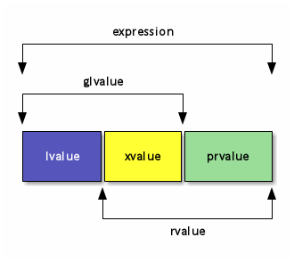

ざっくりと言えば、lvalueとは代入式の左辺になり得る式、rvalueとは代入式の左辺にはなり得ない式である。 T const&は左辺になり得ないが、lvalueである。rvalueリファレンス(T&&)もlvalueであるため、 rvalueであることとrvalueリファレンスであることとは全く異なる。

xvalueとは、多くの場合、「std::move()の呼び出し式のことである」と考えても差し支えない。

prvalueとは、いわゆるテンポラリオブジェクトのことであるため (下記のstd::string()で作られるようなオブジェクト)、名前はない。 また、アドレス演算子(&)のオペランドになれない。

```cpp
    //  example/term_explanation/rvalue_lvalue_ut.cpp 8

    {
        // sを初期化するためにstd::string{}により生成されるオブジェクトはprvalue
        // sはlvalue

        auto s = std::string{};

    #if 0
        // 下記はコンパイルエラー

        auto* sp = &std::string{};
        // 下記はg++のエラーメッセージ
        // programming_convention_type.cpp|709 col 29| error: taking address of rvalue [-fpermissive]
        // ||   709 |     auto* sp = &std::string{};
    #else
        // 下記のようにすればアドレスを取得できるが、このようなことはすべきではない。
        auto&& rvalue_ref = std::string{};
        auto   sp         = &rvalue_ref;
    #endif
        static_assert(std::is_same_v<std::string*, decltype(sp)>);
    }
```

C++11でrvalueの概念の整理やstd::move()の導入が行われた目的はプログラム実行速度の向上である。

- lvalueからの代入
- rvalueからの代入
- std::move(lvalue)からの代入

の処理がどのように違うのかを見ることでrvalueの効果について説明する。

1. 下記コードにより「lvalueからの代入」を説明する。

   ```cpp
   //  example/term_explanation/rvalue_lvalue_ut.cpp 35

   auto str0 = std::string{};        // str0はlvalue
   auto str1 = std::string{"hehe"};  // str1もlvalue
   str0      = str1;                 // lvalueからの代入
   ```

   - ステップ1。 str0、str1がそれぞれ初期化される (“hehe”を保持するバッファが生成され、それをstr1オブジェクトが所有する)。
   - ステップ2。 st1が所有している文字列バッファと等価のバッファが作られ (文字列バッファ用のメモリをnewし、文字列を代入)、 str0がそれを所有する。従って、“hehe”を保持するバッファが2つできる。 この代入をcopy代入と呼ぶ。

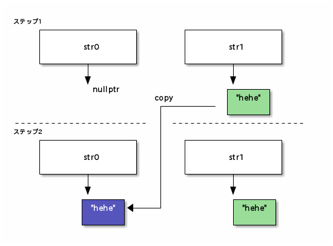

2. 下記コードにより「rvalueからの代入」を説明する。

   ```cpp
   //  example/term_explanation/rvalue_lvalue_ut.cpp 46

   auto str0 = std::string{};        // str0はlvalue
   str0      = std::string{"hehe"};  // rvalueからの代入
   ```

   - ステップ1。str0、「std::string()により作られたテンポラリオブジェクト」がそれぞれ初期化される (“hehe”を保持するバッファが生成され、それをテンポラリオブジェクトが所有する)。
   - ステップ2。 “hehe”を保持する文字列バッファをもう1つ作る代わりに、 テンポラリオブジェクトが所有している文字列バッファをstr0の所有にする。 この代入をmove代入と呼ぶ。
   - ステップ3。 テンポラリオブジェクトが解体されるが、 文字列バッファはstr0の所有であるためdeleteする必要がなく、実際には何もしない。 move代入によって、文字列バッファの生成と破棄の回数がそれぞれ1回少なくなったため、 実行速度は向上する(通常、new/deleteの処理コストは高い)。

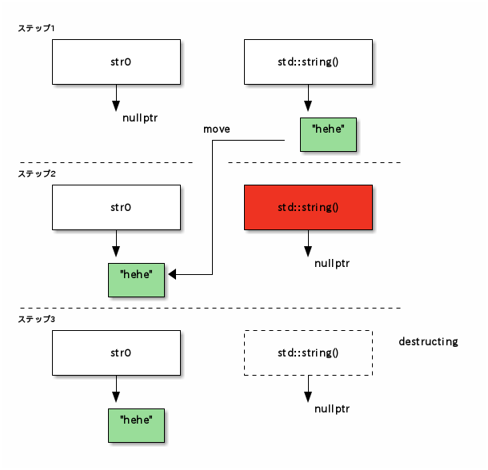

3. 下記コードにより「std::move(lvalue)からの代入」を説明する。

   ```cpp
   //  example/term_explanation/rvalue_lvalue_ut.cpp 56

   auto str0 = std::string{};        // str0はlvalue
   auto str1 = std::string{"hehe"};  // str1もlvalue
   str0      = std::move(str1);      // str1はこれ以降使われないとする
   ```

   - ステップ1。「lvalueからの代入」のステップ1と同じである。
   - ステップ2。 std::move()の効果により(実際にはrvalueリファレンスへのキャストが行われるだけなので、 実行時速度に影響はない)、“hehe”を保持する文字列バッファをもう1つ作る代わりに、 str1が所有している文字列バッファをstr0の所有にする。 この代入もmove代入と呼ぶ。 この動作は「rvalueからの代入」と同じであり、同様に速度が向上するが、その副作用として、 str1.size() == 0となる。

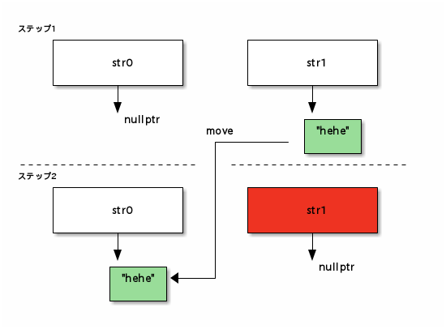

エッセンシャルタイプがTであるlvalue、xvalue、prvalueに対して (例えば、std::string const&のエッセンシャルタイプはstd::stringである)、 decltypeの算出結果は下表のようになる。

| decltype | 算出された型 |
| --- | --- |
| decltype(lvalue) | T |
| decltype((lvalue)) | T& |
| decltype(xvalue) | T&& |
| decltype((xvalue)) | T&& |
| decltype(prvalue) | T |
| decltype((prvalue)) | T |

この表の結果を使用した下記の関数型マクロ群により式を分類できる。 定義から明らかな通り、これらは [テンプレートメタプログラミング](https://ja.wikipedia.org/wiki/%E3%83%86%E3%83%B3%E3%83%97%E3%83%AC%E3%83%BC%E3%83%88%E3%83%A1%E3%82%BF%E3%83%97%E3%83%AD%E3%82%B0%E3%83%A9%E3%83%9F%E3%83%B3%E3%82%B0) に有効に活用できる。

```cpp
    //  example/term_explanation/rvalue_lvalue_ut.cpp 65

    #define IS_LVALUE(EXPR_) std::is_lvalue_reference_v<decltype((EXPR_))>
    #define IS_XVALUE(EXPR_) std::is_rvalue_reference_v<decltype((EXPR_))>
    #define IS_PRVALUE(EXPR_) !std::is_reference_v<decltype((EXPR_))>
    #define IS_RVALUE(EXPR_) (IS_PRVALUE(EXPR_) || IS_XVALUE(EXPR_))

    TEST(Expression, rvalue)
    {
        auto str = std::string{};

        static_assert(IS_LVALUE(str), "EXPR_ must be lvalue");
        static_assert(!IS_RVALUE(str), "EXPR_ must NOT be rvalue");

        static_assert(IS_XVALUE(std::move(str)), "EXPR_ must be xvalue");
        static_assert(!IS_PRVALUE(std::move(str)), "EXPR_ must NOT be prvalue");

        static_assert(IS_PRVALUE(std::string{}), "EXPR_ must be prvalue");
        static_assert(IS_RVALUE(std::string{}), "EXPR_ must be rvalue");
        static_assert(!IS_LVALUE(std::string{}), "EXPR_ must NOT be lvalue");
    }
```

### lvalue

「expression」を参照せよ。

### rvalue

「expression」を参照せよ。

#### xvalue

「expression」を参照せよ。

#### prvalue

「expression」を参照せよ。

### rvalue修飾

下記GetString0()のような関数が返すオブジェクトの内部メンバに対するハンドルは、 オブジェクトのライフタイム終了後にもアクセスすることができるため、 そのハンドルを通じて、 ライフタイム終了後のオブジェクトのメンバオブジェクトにもアクセスできてしまう。

ライフタイム終了後のオブジェクトにアクセスすることは未定義動作であり、 特にそのオブジェクトがrvalueであった場合、さらにその危険性は高まる。

こういったコードに対処するためのシンタックスが、lvalue修飾、rvalue修飾である。

下記GetString1()、GetString3()、GetString4()のようにメンバ関数をlvalue修飾やrvalue修飾することで、 rvalueの内部ハンドルを返さないようにすることが可能となり、上記の危険性を緩和することができる。

```cpp
    //  example/term_explanation/rvalue_lvalue_ut.cpp 91

    class C {
    public:
        explicit C(char const* str) : str_{str} {}

        // lvalue修飾なし、rvalue修飾なし
        std::string& GetString0() noexcept { return str_; }

        // lvalue修飾
        std::string const& GetString1() const& noexcept { return str_; }

        // rvalue修飾
        // *thisがrvalueの場合でのGetString1()の呼び出しは、この関数を呼び出すため、
        // class内部のハンドルを返してはならない。
        // また、それによりstd::stringを生成するため、noexcept指定してはならない。
        std::string GetString1() const&& { return str_; }

        // lvalue修飾だが、const関数はrvalueからでも呼び出せる。
        // rvalueに対しての呼び出しを禁止したい場合には、GetString4のようにする。
        std::string const& GetString2() const& noexcept { return str_; }

        // lvalue修飾
        // 非constなのでrvalueからは呼び出せない。
        std::string const& GetString3() & noexcept { return str_; }

        // lvalue修飾
        std::string const& GetString4() const& noexcept { return str_; }

        // rvalue修飾
        // rvalueからこの関数を呼び出されるとrvalueオブジェクトの内部ハンドルを返してしまい、
        // 危険なので=deleteすべき。
        std::string const& GetString4() const&& = delete;

    private:
        std::string str_;
    };
```

```cpp
    //  example/term_explanation/rvalue_lvalue_ut.cpp 132

    auto        c    = C{"c0"};
    auto const& s0_0 = c.GetString0();        // OK cが解放されるまでs0_0は有効
    auto        s0_1 = C{"c1"}.GetString0();  // NG 危険なコード
    // s0_1が指すオブジェクトは、次の行で無効になる

    auto const& s1_0 = c.GetString1();        // OK GetString1()&が呼び出される
    auto const& s1_1 = C{"c1"}.GetString1();  // OK GetString1()&&が呼び出される
    // s1_0が指すrvalueはs1_0がスコープアウトするまで有効

    auto const& s2_0 = c.GetString2();        // OK GetString2()&が呼び出される
    auto const& s2_1 = C{"c1"}.GetString2();  // NG const関数はlvalue修飾しても呼び出し可能
    // s2_1が指すオブジェクトは、次の行で無効になる

    auto const& s3_0 = c.GetString3();  // OK GetString3()&が呼び出される
    // auto const& s3_1 = C{"c1"}.GetString3();  // 危険なのでコンパイルさせない

    auto const& s4_0 = c.GetString4();  // OK GetString4()&が呼び出される
    // auto const& s4_1 = C{"c1"}.GetString4();  // 危険なのでコンパイルさせない
```

### lvalue修飾

rvalue修飾を参照せよ。

### リファレンス修飾

rvalue修飾とlvalue修飾とを併せて、リファレンス修飾と呼ぶ。

## リファレンス

ここでは、C++11から導入された

- ユニバーサルリファレンス
- リファレンスcollapsing

について解説する。

### ユニバーサルリファレンス

関数テンプレートの型パラメータや型推論autoに&&をつけて宣言された変数を、 ユニバーサルリファレンスと呼ぶ(C++17から「forwardingリファレンス」という正式名称が与えられた)。 ユニバーサルリファレンスは一見rvalueリファレンスのように見えるが、 下記に示す通り、lvalueにもrvalueにもバインドできる。

```cpp
    //  example/term_explanation/universal_ref_ut.cpp 8

    template <typename T>
    void f(T&& t) noexcept  // tはユニバーサルリファレンス
    {
        ...
    }

    template <typename T>
    void g(std::vector<T>&& t) noexcept  // tはrvalueリファレンス
    {
        ...
    }
```

```cpp
    //  example/term_explanation/universal_ref_ut.cpp 29

    auto       vec  = std::vector<std::string>{"lvalue"};   // vecはlvalue
    auto const cvec = std::vector<std::string>{"clvalue"};  // cvecはconstなlvalue

    f(vec);                                 // 引数はlvalue
    f(cvec);                                // 引数はconstなlvalue
    f(std::vector<std::string>{"rvalue"});  // 引数はrvalue

    // g(vec);  // 引数がlvalueなのでコンパイルエラー
    // g(cvec); // 引数がconst lvalueなのでコンパイルエラー
    g(std::vector<std::string>{"rvalue"});  // 引数はrvalue
```

下記のコードはジェネリックラムダの引数をユニバーサルリファレンスにした例である。

```cpp
    //  example/term_explanation/universal_ref_ut.cpp 47

    // sはユニバーサルリファレンス
    auto value_type = [](auto&& s) noexcept {
        if (std::is_same_v<std::string&, decltype(s)>) {
            return 0;
        }
        if (std::is_same_v<std::string const&, decltype(s)>) {
            return 1;
        }
        if (std::is_same_v<std::string&&, decltype(s)>) {
            return 2;
        }
        return 3;
    };

    auto       str  = std::string{"lvalue"};
    auto const cstr = std::string{"const lvalue"};

    ASSERT_EQ(0, value_type(str));
    ASSERT_EQ(1, value_type(cstr));
    ASSERT_EQ(2, value_type(std::string{"rvalue"}));
```

通常、ユニバーサルリファレンスはstd::forwardと組み合わせて使用される。

### forwardingリファレンス

「ユニバーサルリファレンス」を参照せよ。

### perfect forwarding

perfect forwarding とは、引数のrvalue性や lvalue性を損失することなく、 その引数を別の関数に転送する技術のことを指す。 通常は、ユニバーサルリファレンスである関数の仮引数をstd::forwardを用いて、 他の関数に渡すことで実現される。

### リファレンスcollapsing

Tを任意の型とし、TRを下記のように宣言した場合、

```cpp
    using TR = T&;
```

下記のようなコードは、C++03ではコンパイルエラーとなったが、 C++11からはエラーとならず、TRRはT&となる。

```cpp
    using TRR = TR&;
```

2つの&を1つに折り畳む、このような機能をリファレンスcollapsingと呼ぶ。

下記はTをintとした場合のリファレンスcollapsingの動きを示している。

```cpp
    //  example/term_explanation/ref_collapsing_ut.cpp 7

    int i;

    using IR  = int&;
    using IRR = IR&;  // IRRはint& &となり、int&に変換される

    IR  ir  = i;
    IRR irr = ir;

    static_assert(std::is_same_v<int&, decltype(ir)>);   // lvalueリファレンス
    static_assert(std::is_same_v<int&, decltype(irr)>);  // lvalueリファレンス
```

リファレンスcollapsingは、型エイリアス、型であるテンプレートパラメータ、decltypeに対して行われる。 詳細な変換則は、下記のようになる。

```
    T& &   -> T&
    T& &&  -> T&
    T&& &  -> T&
    T&& && -> T&&
```

下記のようなクラステンプレートを定義した場合、

```cpp
    //  example/term_explanation/ref_collapsing_ut.cpp 26

    template <typename T>
    struct Ref {
        T&  t;
        T&& u;
    };
```

下記のコードにより、テンプレートパラメータに対するこの変換則を確かめることができる。

```cpp
    //  example/term_explanation/ref_collapsing_ut.cpp 38

    static_assert(std::is_same_v<int&, decltype(Ref<int>::t)>);    // lvalueリファレンス
    static_assert(std::is_same_v<int&&, decltype(Ref<int>::u)>);   // rvalueリファレンス

    static_assert(std::is_same_v<int&, decltype(Ref<int&>::t)>);   // lvalueリファレンス
    static_assert(std::is_same_v<int&, decltype(Ref<int&>::u)>);   // lvalueリファレンス

    static_assert(std::is_same_v<int&, decltype(Ref<int&&>::t)>);  // lvalueリファレンス
    static_assert(std::is_same_v<int&&, decltype(Ref<int&&>::u)>); // rvalueリファレンス
```

この機能がないC++03では、

```cpp
    //  example/term_explanation/ref_collapsing_ut.cpp 52

    template <typename T>
    struct AddRef {
        using type = T&;
    };
```

ようなクラステンプレートに下記コードのようにリファレンス型を渡すとコンパイルエラーとなる。

```cpp
    //  example/term_explanation/ref_collapsing_ut.cpp 69

    static_assert(std::is_same_v<int&, AddRef<int&>::type>);
```

この問題を回避するためには下記のようなテンプレートの特殊化が必要になる。

```cpp
    //  example/term_explanation/ref_collapsing_ut.cpp 59

    template <typename T>
    struct AddRef<T&> {
        using type = T&;
    };
```

上記したようなクラステンプレートでのメンバエイリアスの宣言は、 [テンプレートメタプログラミング](https://ja.wikipedia.org/wiki/%E3%83%86%E3%83%B3%E3%83%97%E3%83%AC%E3%83%BC%E3%83%88%E3%83%A1%E3%82%BF%E3%83%97%E3%83%AD%E3%82%B0%E3%83%A9%E3%83%9F%E3%83%B3%E3%82%B0) で頻繁に使用されるため、 このようなテンプレートの特殊化を不要にするリファレンスcollapsingは、 有用な機能拡張であると言える。

### danglingリファレンス

Dangling リファレンスとは、破棄後のオブジェクトを指しているリファレンスを指す。 このようなリファレンスにアクセスすると、未定義動作に繋がるに繋がる。

```cpp
    //  example/term_explanation/dangling_ut.cpp 9

    bool X_destructed;
    class X {
    public:
        X() { X_destructed = false; }
        ~X() { X_destructed = true; }
    };

    bool A_destructed;
    class A {
    public:
        A() { A_destructed = false; }
        ~A() { A_destructed = true; }

        X const& GetX() const noexcept { return x_; }

    private:
        X x_;
    };

    //  example/term_explanation/dangling_ut.cpp 34

    auto a = A{};

    auto const& x_safe = a.GetX();  // x_safeはダングリングリファレンスではない
    ASSERT_FALSE(A_destructed || X_destructed);

    auto const& x_dangling = A{}.GetX();  // 次の行でxが指すオブジェクトは解放される
    // この行ではxはdangngling リファレンスになる。
    ASSERT_TRUE(A_destructed && X_destructed);

    auto const* x_ptr_dangling = &A{}.GetX();  // 次の行でxが指すオブジェクトは解放される
    // この行ではxはdangngling ポインタになる。
    ASSERT_TRUE(A_destructed && X_destructed);
```

### danglingポインタ

danglingポインタとは、danglingリファレンスと同じような状態になったポインタを指す。

## エクセプション安全性の保証

関数のエクセプション発生時の安全性の保証には以下の3つのレベルが規定されている。

- no-fail保証
- 強い安全性の保証
- 基本的な安全性の保証

### no-fail保証

「no-fail保証」を満たす関数はエクセプションをthrowしない。 no-failを保証する関数は、 noexceptを使用してエクセプションを発生させないことを明示できる。

標準テンプレートクラスのパラメータとして使用するクラスのメンバ関数には、 正確にnoexceptの宣言をしないと、 テンプレートクラスのメンバ関数によってはパフォーマンスを起こしてしまう可能性がある。

### 強い安全性の保証

「強い保証」を満たす関数は、この関数がエクセプションによりスコープから外れた場合でも、 この関数が呼ばれなかった状態と同じ(プログラムカウンタ以外の状態は同じ)であることを保証する。 従って、この関数呼び出しは成功したか、完全な無効だったかのどちらかになる。

### 基本的な安全性の保証

「基本的な安全性の保証」を満たす関数は、この関数がエクセプションによりスコープから外れた場合でも、 メモリ等のリソースリークは起こさず、 オブジェクトは(変更されたかもしれないが)引き続き使えることを保証する。

### noexcept

C++11で導入されたnoexceptキーワードには、以下の2つの意味がある。

- C++03までのthrowキーワードによる例外仕様の代替。 関数がどの例外を送出する可能性があるかを列挙するのではなく、 例外を送出する可能性があるかないかのみを指定する。
- sizeofと同じような形式で使用されるのような演算子としてのnoexceptは、 noexcept(expression)の形式使用され、 expressionがエクセプションを送出しないと宣言されている場合(noexceptと宣言された関数の呼び出し)、 noexcept(expression)は静的にtrueとなる。

以下に上記のコード例を示す。

```cpp
    //  example/term_explanation/noexcept_ut.cpp 11

    std::string f_noexcept() noexcept  // エクセプションを発生させない
    {
        return "No exceptions here!";
    }

    std::string f_except() noexcept(false)  // エクセプションを発生させる
    {
        throw std::runtime_error{"always throw"};

        return "No exceptions here!";
    }

    // noexcept or noexcept(false)と宣言しない限りnoexceptでない
    std::string f_except2()  // エクセプションを発生させる
    {
        throw std::runtime_error{"always throw"};

        return "No exceptions here!";
    }
```

```cpp
    //  example/term_explanation/noexcept_ut.cpp 37

    static_assert(noexcept(f_noexcept()));  // エクセプションを発生させる可能性の確認
    static_assert(!noexcept(f_except()));   // エクセプションを発生させない可能性の確認
    static_assert(!noexcept(f_except2()));  // エクセプションを発生させない可能性の確認

    ASSERT_EQ(f_noexcept(), "No exceptions here!");  // 動作確認
    ASSERT_THROW(f_except(), std::runtime_error);    // エクセプションの発生確認
    ASSERT_THROW(f_except2(), std::runtime_error);   // エクセプションの発生確認
```

演算子としてのnoexceptはテンプレートで頻繁に使用されるため、以下にそのような例を示す。

```cpp
    //  example/term_explanation/noexcept_ut.cpp 50

    class PossiblyThrow {  // オブジェクト生成でエクセプションの発生可能性あり
    public:
        PossiblyThrow() {}
    };

    // テンプレート型Tがnoexceptで生成可能なら、関数もnoexceptにする
    template <typename T>
    void t_f(T const&) noexcept(std::is_nothrow_constructible_v<T>)
    {
        // Tを生成して、何らかの処理を行う
    }
```

```cpp
    //  example/term_explanation/noexcept_ut.cpp 67

    auto i = int{};
    auto p = PossiblyThrow{};

    static_assert(!std::is_nothrow_constructible_v<PossiblyThrow>);
    static_assert(std::is_nothrow_constructible_v<decltype(i)>);
    static_assert(noexcept(t_f(i)));
    static_assert(!noexcept(t_f(p)));
```

### exception-unfriendly

以下のような関数

- 初期化に関連する関数やコンストラクタ
  - 静的または thread_local な変数を初期化する関数やコンストラクタ
- 特殊メンバ関数
  - すべてのデストラクタ
  - すべての例外オブジェクトのコピーコンストラクタ
  - すべてのムーブコンストラクタ
  - すべてのムーブ代入演算子
- 特定の名前を持つ関数
  - “swap” という名前のすべての関数
- C言語との互換性を持つ関数
  - Cとのリンケージを持つすべての関数

の呼び出しでエクセプションがthrowされると、未定義動作や未規定動作が発生するため、 exception-unfriendly(エクセプションに不向き)であるとされる。 従って上記の関数は暗黙的または明示的に`noexcept`であることが求められる。

## シンタックス、セマンティクス

直訳すれば、シンタックスとは構文論のことであり、セマンティクスとは意味論のことである。 この二つの概念の違いをはっきりと際立たせる有名な文を例示する。

```
    Colorless green ideas sleep furiously(直訳:無色の緑の考えが猛烈に眠る)
```

この文は構文的には正しい(シンタックスは問題ない)が、 意味不明である(セマンティクスは誤り)。

C++プログラミングにおいては、コンパイルできることがシンタックス的な正しさであり、例えば

- クラスや関数がその名前から想起できる責務を持っている
  - 「単一責任の原則(SRP)」を満たしている
  - Accessorを実装する関数の名前は、GetXxxやSetXxxになっている
  - コンテナクラスのメンバ関数beginやendは、 そのクラスが保持する値集合の先頭や最後尾の次を指すイテレータを返す
  - 等
- 「等価性のセマンティクス」を守ってる
- 「copyセマンティクス」を守ってる
- 「moveセマンティクス」を守っている

等がセマンティクス的な正しさである。

セマンティクス的に正しいソースコードは読みやすく、保守性、拡張性に優れている。

### 等価性のセマンティクス

純粋数学での実数の等号(=)は、任意の実数x、y、zに対して、

| 律 | 意味 |
| --- | --- |
| 反射律 | x = x |
| 対称律 | x = yならばy = x |
| 推移律 | x = y且つy = zならばx = z |

を満たしている。x = yが成立する場合、「xはyと等しい」もしくは「xはyと同一」であると言う。

C++における組み込みの==も純粋数学の等号と同じ性質を満たしている。 下記のコードは、その性質を表している。

```cpp
    //  example/term_explanation/semantics_ut.cpp 13

    auto  a = 0;
    auto& b = a;

    ASSERT_TRUE(a == b);
    ASSERT_TRUE(&a == &b);  // aとbは同一
```

しかし、下記のコード内のa、bは同じ値を持つが、 アドレスが異なるため同一のオブジェクトではないにもかかわらず、組み込みの==の値はtrueとなる。

```cpp
    //  example/term_explanation/semantics_ut.cpp 23

    auto a = 0;
    auto b = 0;

    ASSERT_TRUE(a == b);
    ASSERT_FALSE(&a == &b);  // aとbは同一ではない
```

このような場合、aとbは等価であるという。同一ならば等価であるが、等価であっても同一とは限らない。

ポインタや配列をオペランドとする場合を除き、C++における組み込みの==は、 数学の等号とは違い、等価を表していると考えられるが、 上記した3つの律を守っている。従ってオーバーロードoperator==も同じ性質を守る必要がある。

組み込みの==やオーバーロード==演算子のこのような性質をここでは「等価性のセマンティクス」と呼ぶ。

クラスAを下記のように定義し、

```cpp
    //  example/term_explanation/semantics_ut.cpp 34

    class A {
    public:
        explicit A(int num, char const* name) noexcept : num_{num}, name_{name} {}

        int         GetNum() const noexcept { return num_; }
        char const* GetName() const noexcept { return name_; }

    private:
        int const   num_;
        char const* name_;
    };
```

そのoperator==を下記のように定義した場合、

```cpp
    //  example/term_explanation/semantics_ut.cpp 51

    inline bool operator==(A const& lhs, A const& rhs) noexcept
    {
        return std::tuple(lhs.GetNum(), lhs.GetName()) == std::tuple(rhs.GetNum(), rhs.GetName());
    }
```

単体テストは下記のように書けるだろう。

```cpp
    //  example/term_explanation/semantics_ut.cpp 62

    auto a0 = A{0, "a"};
    auto a1 = A{0, "a"};

    ASSERT_TRUE(a0 == a1);
```

これは、一応パスするが(処理系定義の動作を前提とするため、必ず動作する保証はない)、 下記のようにすると、パスしなくなる。

```cpp
    //  example/term_explanation/semantics_ut.cpp 72

    char a0_name[] = "a";
    auto a0        = A{0, a0_name};

    char a1_name[] = "a";
    auto a1        = A{0, a1_name};

    ASSERT_TRUE(a0 == a1);  // テストが失敗する
```

一般にポインタの等価性は、その値の同一性ではなく、 そのポインタが指すオブジェクトの等価性で判断されるべきであるが、 先に示したoperator==はその考慮をしていないため、このような結果になった。

次に、これを修正した例を示す。

```cpp
    //  example/term_explanation/semantics_ut.cpp 91

    inline bool operator==(A const& lhs, A const& rhs) noexcept
    {
        return std::tuple(lhs.GetNum(), std::string_view{lhs.GetName()})
               == std::tuple(rhs.GetNum(), std::string_view{rhs.GetName()});
    }
```

ポインタをメンバに持つクラスのoperator==については、上記したような処理が必要となる。

次に示す例は、基底クラスBaseとそのoperator==である。

```cpp
    //  example/term_explanation/semantics_ut.cpp 114

    class Base {
    public:
        explicit Base(int b) noexcept : b_{b} {}
        virtual ~Base() = default;
        int GetB() const noexcept { return b_; }

    private:
        int b_;
    };

    inline bool operator==(Base const& lhs, Base const& rhs) noexcept
    {
        return lhs.GetB() == rhs.GetB();
    }
```

次の単体テストが示す通り、これ自体には問題がないように見える。

```cpp
    //  example/term_explanation/semantics_ut.cpp 134

    auto b0 = Base{0};
    auto b1 = Base{0};
    auto b2 = Base{1};

    ASSERT_TRUE(b0 == b0);
    ASSERT_TRUE(b0 == b1);
    ASSERT_FALSE(b0 == b2);
```

しかし、Baseから派生したクラスDerivedを

```cpp
    //  example/term_explanation/semantics_ut.cpp 146

    class Derived : public Base {
    public:
        explicit Derived(int d) noexcept : Base{0}, d_{d} {}
        int GetD() const noexcept { return d_; }

    private:
        int d_;
    };
```

のように定義すると、下記の単体テストで示す通り、等価性のセマンティクスが破壊される。

```cpp
    //  example/term_explanation/semantics_ut.cpp 160

    {
        auto b = Base{0};
        auto d = Derived{1};

        ASSERT_TRUE(b == d);  // NG bとdは明らかに等価でない
    }
    {
        auto d0 = Derived{0};
        auto d1 = Derived{1};

        ASSERT_TRUE(d0 == d1);  // NG d0とd1は明らかに等価ではない
    }
```

Derived用のoperator==を

```cpp
    //  example/term_explanation/semantics_ut.cpp 177

    bool operator==(Derived const& lhs, Derived const& rhs) noexcept
    {
        return std::tuple(lhs.GetB(), lhs.GetD()) == std::tuple(rhs.GetB(), rhs.GetD());
    }
```

と定義しても、下記に示す通り部分的な効果しかない。

```cpp
    //  example/term_explanation/semantics_ut.cpp 187

    auto d0 = Derived{0};
    auto d1 = Derived{1};

    ASSERT_FALSE(d0 == d1);  // OK operator==(Derived const&, Derived const&)の効果で正しい判定

    Base& d0_b_ref = d0;

    ASSERT_TRUE(d0_b_ref == d1);  // NG d0_b_refの実態はd0なのでd1と等価でない
```

この問題は、「RTTI」使った下記のようなコードで対処できる。

```cpp
    //  example/term_explanation/semantics_ut.cpp 203

    class Base {
    public:
        explicit Base(int b) noexcept : b_{b} {}
        virtual ~Base() = default;
        int GetB() const noexcept { return b_; }

    protected:
        virtual bool is_equal(Base const& rhs) const noexcept { return b_ == rhs.b_; }

    private:
        int b_;

        friend inline bool operator==(Base const& lhs, Base const& rhs) noexcept
        {
            if (typeid(lhs) != typeid(rhs)) {
                return false;
            }

            return lhs.is_equal(rhs);
        }
    };

    class Derived : public Base {
    public:
        explicit Derived(int d) : Base{0}, d_{d} {}
        int GetD() const noexcept { return d_; }

    protected:
        virtual bool is_equal(Base const& rhs) const noexcept
        {
            // operator==によりrhsの型はDerivedであるため、下記のキャストは安全
            auto const& rhs_d = static_cast<Derived const&>(rhs);

            return Base::is_equal(rhs) && d_ == rhs_d.d_;
        }

    private:
        int d_;
    };
```

下記に示す通り、このコードは、 オープン・クローズドの原則(OCP)にも対応した柔軟な構造を実現している。

```cpp
    //  example/term_explanation/semantics_ut.cpp 270

    class DerivedDerived : public Derived {
    public:
        explicit DerivedDerived(int dd) noexcept : Derived{0}, dd_{dd} {}
        int GetDD() const noexcept { return dd_; }

    protected:
        virtual bool is_equal(Base const& rhs) const noexcept
        {
            // operator==によりrhsの型はDerivedDerivedであるため、下記のキャストは安全
            auto const& rhs_d = static_cast<DerivedDerived const&>(rhs);

            return Derived::is_equal(rhs) && dd_ == rhs_d.dd_;
        }

    private:
        int dd_;
    };
```

前例では「両辺の型が等しいこと」が「等価であること」の必要条件となるが、 この要件が、すべてのoperator==に求められるわけではない。

次に示すのは、一見すると両辺の型が違うにもかかわらず、 等価性のセマンティクスを満たしている例である。

```cpp
    //  example/term_explanation/semantics_ut.cpp 320

    auto abc = std::string{"abc"};

    ASSERT_TRUE("abc" == abc);
    ASSERT_TRUE(abc == "abc");
```

これは、文字列リテラルを第1引数に取るstd::stringのコンストラクタが非explicitであることによって、 文字列リテラルからstd::stringへの暗黙の型変換が起こるために成立する。

以上で見てきたように、等価性のセマンティクスを守ったoperator==の実装には多くの観点が必要になる。

### copyセマンティクス

copyセマンティクスとは以下を満たすようなセマンティクスである。

- a = bが行われた後に、aとbが等価である。
- a = bが行われた前後でbの値が変わっていない。

従って、これらのオブジェクトに対して等価性のセマンティクス を満たすoperator==が定義されている場合、 以下を満たすようなセマンティクスであると言い換えることができる。

- a = bが行われた後に、a == bがtrueになる。
- b == b_preがtrueの時に、a = bが行われた後でもb == b_preがtrueとなる。

下記に示す通り、std::stringはcopyセマンティクスを満たしている。

```cpp
    //  example/term_explanation/semantics_ut.cpp 334

    auto c_str = "string";
    auto str   = std::string{};

    str = c_str;
    ASSERT_TRUE(c_str == str);      // = 後には == が成立している
    ASSERT_STREQ("string", c_str);  // c_strの値は変わっていない
```

一方で、std::auto_ptrはcopyセマンティクスを満たしていない。

```cpp
    //  example/term_explanation/semantics_ut.cpp 347

    std::auto_ptr<std::string> str0{new std::string{"string"}};
    std::auto_ptr<std::string> str0_pre{new std::string{"string"}};

    ASSERT_TRUE(*str0 == *str0_pre);  // 前提は成立

    std::auto_ptr<std::string> str1;

    str1 = str0;

    // ASSERT_TRUE(*str0 == *str0_pre);  // これをするとクラッシュする
    ASSERT_TRUE(str0.get() == nullptr);  // str0の値がoperator ==で変わってしまった

    ASSERT_TRUE(*str1 == *str0_pre);  // これは成立
```

この仕様は極めて不自然であり、std::auto_ptrはC++11で非推奨となり、C++17で規格から排除された。

下記の単体テストから明らかな通り、 「等価性のセマンティクス」で示した最後の例も、copyセマンティクスを満たしていない。

```cpp
    //  example/term_explanation/semantics_ut.cpp 367

    auto b = Base{1};
    auto d = Derived{1};

    b = d;  // スライシングが起こる

    ASSERT_FALSE(b == d);  // copyセマンティクスを満たしていない
```

原因は、copy代入でスライシングが起こるためである。

### moveセマンティクス

moveセマンティクスとは以下を満たすようなセマンティクスである(operator==が定義されていると前提)。

- copy代入の実行コスト >= move代入の実行コスト
- a == bがtrueの時に、c = std::move(a)が行われた場合、
  - b == cがtrueになる。
  - a == cはtrueにならなくても良い(aはmove代入により破壊されるかもしれない)。

  必須ではないが、「aがポインタ等のリソースを保有している場合、move代入後には、 そのリソースはcに移動している」ことが一般的である(「rvalue」参照)。
- no-fail保証をする(noexceptと宣言し、エクセプションをthrowしない)。

moveセマンティクスはcopy代入後に使用されなくなるオブジェクト(主にrvalue) からのcopy代入の実行コストを下げるために導入されたため、 下記のようなコードは推奨されない。

```cpp
    //  example/term_explanation/semantics_ut.cpp 382

    class NotRecommended {
    public:
        NotRecommended(char const* name) : name_{name} {}
        std::string const& Name() const noexcept { return name_; }

        NotRecommended& operator=(NotRecommended&& rhs)  // move代入、非no-fail保証
        {
            name_ = rhs.name_;  // rhs.name_からname_へのcopy代入。パフォーマンス問題になるかも。
            return *this;
        }

    private:
        std::string name_;
    };

    bool operator==(NotRecommended const& lhs, NotRecommended const& rhs) noexcept
    {
        return lhs.Name() == rhs.Name();
    }

    TEST(Semantics, move1)
    {
        auto a = NotRecommended{"a"};
        auto b = NotRecommended{"a"};

        ASSERT_EQ("a", a.Name());
        ASSERT_TRUE(a == b);

        auto c = NotRecommended{"c"};
        ASSERT_EQ("c", c.Name());

        c = std::move(a);
        ASSERT_TRUE(b == c);  // 一応、moveセマンティクスは守っているが・・・
    }
```

下記のコードのようにメンバの代入もできる限りmove代入を使うことで、 パフォーマンスの良い代入ができる。

```cpp
    //  example/term_explanation/semantics_ut.cpp 420

    class Recommended {
    public:
        Recommended(char const* name) : name_{name} {}
        std::string const& Name() const noexcept { return name_; }

        Recommended& operator=(Recommended&& rhs) noexcept  // move代入、no-fail保証
        {
            name_ = std::move(rhs.name_);  // rhs.name_からname_へのmove代入
            return *this;
        }

    private:
        std::string name_;
    };

    bool operator==(Recommended const& lhs, Recommended const& rhs) noexcept
    {
        return lhs.Name() == rhs.Name();
    }

    TEST(Semantics, move2)
    {
        auto a = Recommended{"a"};
        auto b = Recommended{"a"};

        ASSERT_EQ("a", a.Name());
        ASSERT_TRUE(a == b);

        auto c = Recommended{"c"};
        ASSERT_EQ("c", c.Name());

        c = std::move(a);     // これ以降aは使ってはならない
        ASSERT_TRUE(b == c);  // moveセマンティクスを正しく守っている
    }
```

### MoveAssignable要件

MoveAssignable要件は、C++において型がムーブ代入をサポートするために満たすべき条件を指す。 ムーブ代入はリソースを効率的に転送する操作であり、以下の条件を満たす必要がある。

1. リソースの移動  
   ムーブ代入では、リソース(動的メモリ等)が代入元から代入先へ効率的に転送される。
2. 有効だが未定義の状態  
   ムーブ代入後、代入元のオブジェクトは有効ではあるが未定義の状態となる。 未定義の状態とは、破棄や再代入が可能である状態を指し、それ以外の操作は保証されない。
3. 自己代入の安全性  
   同一のオブジェクトをムーブ代入する場合でも、未定義動作やリソースリークを引き起こしてはならない。
4. 効率性  
   ムーブ代入は通常、コピー代入よりも効率的であることが求められる。 これは、リソースの複製を避けることで達成される(「moveセマンティクス」参照)。
5. デフォルト実装  
   ムーブ代入演算子が明示的に定義されていない場合でも、 クラスが一定の条件(例: ムーブ不可能なメンバが存在しないこと)を満たしていれば、 コンパイラがデフォルトの実装(「特殊メンバ関数」参照)を生成する。

### CopyAssignable要件

CopyAssignable要件は、C++において型がコピー代入をサポートするために満たすべき条件を指す。

1. 動作が定義されていること  
   代入操作は未定義動作を引き起こしてはならない。自己代入（同じオブジェクトを代入する場合）においても正しく動作し、リソースリークを引き起こさないことが求められる。
2. 値の保持  
   代入後、代入先のオブジェクトの値は代入元のオブジェクトの値と一致していなければならない。
3. 正しいセマンティクス  
   コピー代入によって代入元のオブジェクトが変更されてはならない(「copyセマンティクス」参照)。 代入先のオブジェクトが保持していたリソース(例: メモリ)は適切に解放される必要がある。
4. デフォルト実装  
   コピー代入演算子が明示的に定義されていない場合でも、 クラスが一定の条件(例: コピー不可能なメンバが存在しないこと)を満たしていれば、 コンパイラがデフォルトの実装(「特殊メンバ関数」参照)を生成する。

## C++その他

### 型特性キーワード

アライメントとは、 データが効率的にアクセスされるために特定のメモリアドレス境界に配置される規則である。 C++03までの規約では、アライメントのコントロールは実装依存した#pragmaなどで行っていた。

alignas、 alignofによりコンパイラの標準的な方法でアライメントのコントロールできるようになった。

#### alignof

C++11で導入されたキーワードで、型のアライメント要求を取得するために使用する。

```cpp
    //  example/term_explanation/aliging_ut.cpp 12

    struct alignas(16) AlignedStruct {  // メモリ上で16バイト境界にアライメントされる
        char   a;
        double x;
        double y;
    };

    AlignedStruct a;

    uintptr_t address = reinterpret_cast<uintptr_t>(&a);  // aのアドレスを取得

    ASSERT_EQ(address % 16, 0);             // アドレスが16の倍数であることを確認
    ASSERT_EQ(alignof(AlignedStruct), 16);  // アライメントが正しいか確認
```

#### alignas

C++11で導入されたキーワードで、メモリのアライメントを指定するために使用する。

```cpp
    //  example/term_explanation/aliging_ut.cpp 27

    ASSERT_EQ(alignof(long double), 16);  // アライメントが正しいか確認
    ASSERT_EQ(alignof(long long), 8);     // アライメントが正しいか確認
    ASSERT_EQ(alignof(void*), 8);         // アライメントが正しいか確認
    ASSERT_EQ(alignof(int), 4);           // アライメントが正しいか確認
```

#### addressof

addressofは、オブジェクトの「実際の」 アドレスを取得するために使用されるC++標準ライブラリのユーティリティ関数である。 通常、オブジェクトのアドレスを取得するには&演算子を使うが、 operator& がオーバーロードされている場合には、 &演算子ではオブジェクトのメモリ上の実際のアドレスを取得できない場合があり得る。 そのような場合にstd::addressofすることにより、 オーバーロードを無視して元のアドレスを確実に取得できる。

```cpp
    //  example/term_explanation/aliging_ut.cpp 38

    class X {
    public:
        explicit X(int v) : v_{v} {}

        X* operator&()
        {  // `operator&` をオーバーロードしてアドレス取得の挙動を変更
            return nullptr;  // 意図的に nullptr を返す
        }
        operator int() const noexcept { return v_; }

    private:
        int v_;
    };
```

```cpp
    //  example/term_explanation/aliging_ut.cpp 54

    X obj{42};

    X* p0 = &obj;  // &演算子で取得するアドレス(オーバーロードされているためnullptr が返る)
    ASSERT_EQ(p0, nullptr);

    // std::addressofとほぼ同じ実装であるラムダ
    auto addressof = [](auto& arg) noexcept {
        return reinterpret_cast<std::remove_reference_t<decltype(arg)>*>(
            &const_cast<char&>(reinterpret_cast<const volatile char&>(arg)));
    };

    // ラムダaddressofを使用して強引にobjのアドレスを取得
    X* p1 = addressof(obj);
    ASSERT_NE(p1, nullptr);

    int* i_ptr = reinterpret_cast<int*>(p1);  // 処理系依存だが、通常の32/64bit環境なら通る
    ASSERT_EQ(42, *i_ptr);

    X* p2 = std::addressof(obj);
    ASSERT_EQ(p1, p2);
```

### 演算子のオペランドの評価順位

C++17で、演算子のオペランドに対する評価順序が明確に規定された。 それに対し、C++14までは、演算子のオペランド部分式の評価順序は未規定動作であった。 以下の表で示す演算子に関しては、オペランドaがオペランドbよりも先に評価される。

| 演算子 | 説明 |
| --- | --- |
| a.b | メンバアクセス演算子 |
| a->b | ポインタメンバアクセス演算子 |
| a->*b | メンバポインタアクセス演算子 |
| a(b1, b2, b3) | 関数呼び出し、引数リストの評価順序は規定外) |
| b @= a | 代入演算子 = や複合代入演算子。@は+,-,/,&,\|など |
| a[b] | 配列アクセス |
| a << b | ビットシフト左演算子 |
| a >> b | ビットシフト右演算子 |

```cpp
    //  example/term_explanation/etc_ut.cpp 22

    int i = 0;
    int y = (i = 1) * x + (i = 2);

    a(b1, b2, b3);  // b1, b2, b3の評価順序は規定外
```

関数呼び出しにおける引数の式の評価順序は、上記の例a(b1, b2, b3)での評価順序は、 不定順で序列化される。これは、b1, b2, b3 が特定の順序で評価される保証はなく、 例えば b3, b2, b1 の順に評価されたり、 b2, b3, b1 で評価される可能性があることを意味する。 一方で一度評価が開始された場合、部分式間でインターリーブ（交差実行されることはない。 つまり、b1 の評価が完全に終わる前に b2 や b3 の評価が開始されることはない。

条件演算子式`condition ? expr1 : expr2`については、 最初の部分であるconditionがまず評価される。 conditionの評価結果に基づき、expr1または expr2 のどちらかが選択され、選択された側だけが評価される。

```cpp
    //  example/term_explanation/etc_ut.cpp 31

    int a      = 1;
    int b      = 2;
    int result = (a < b) ? func1() : func2();
```

なお、単項演算子のオペランドは1つであるため、優先順位の定義は不要である。

### 実引数/仮引数

引数(もしくは実引数、argument)、仮引数(parameter)とは下記のように定義される。

```cpp
    //  example/term_explanation/argument.cpp 2

    int f0(int a, int& b) noexcept  // a, bは仮引数
    {
        ...
    }

    void f1() noexcept
    {
        ...

        f0(x, y);  // x, yは実引数
    }
```

### 単純代入

代入は下記のように分類される。

- 単純代入(=)
- 複合代入(+=，++ 等)

### ill-formed

[標準規格と処理系](https://cpprefjp.github.io/implementation-compliance.html)に詳しい解説があるが、

- well-formed(適格)とはプログラムが全ての構文規則・診断対象の意味規則・ 単一定義規則を満たすことである。
- ill-formed(不適格)とはプログラムが適格でないことである。

プログラムがwell-formedになった場合、そのプログラムはコンパイルできる。 プログラムがill-formedになった場合、通常はコンパイルエラーになるが、 対象がテンプレートの場合、事情は少々異なり、SFINAEによりコンパイルできることもある。

### well-formed

「ill-formed」を参照せよ。

### 未定義動作

未定義動作(Undefined Behavior)とは、 C++標準が特定の操作や状況に対して一切の制約を設けないケースである。 未定義動作が発生すると、プログラムの実行結果が予測できなくなり、 何が起こるかはコンパイラや環境によって異なる。 未定義動作を含むコードは、クラッシュやセキュリティの問題を引き起こす可能性がある。

```cpp
    //  example/term_explanation/undefined_ut.cpp 14

    int a = 42;
    int b = 0;
    int c = a / b;  // 未定義動作 - ゼロ除算

    int arr[]{1, 2, 3};
    int x = arr[index];  // 未定義動作 - index>2の場合、配列範囲外アクセス
```

### 未規定動作

未規定動作(Unspecified Behavior)とは、C++標準がある操作の動作を完全には決めておらず、 複数の許容可能な選択肢がある場合でのコードの動作を指す。 未規定動作は、実装ごとに異なる可能性があり、標準は少なくとも「何らかの合理的な結果」を保証する。 つまり、動作が特定の範囲で予測可能だが、正確な挙動が処理系の実装に依存することになる。

```cpp
    //  example/term_explanation/undefined_ut.cpp 35

    enum class MyEnum : int { Value1 = 1, Value2 = 256 };
    int value = static_cast<int8_t>(MyEnum::Value2);  // 未規定 - 256はint8_tとして表現できない

    auto a      = int{5};
    auto lambda = [](auto a0, auto a1) { return a0 / a1; };
    auto result = lambda(a++, a++);  // 未規定 - 引数評価の順序が決まっていない
```

### 未定義動作と未規定動作

| 種類 | 定義 | 例 | 結果 |
| --- | --- | --- | --- |
| 未定義動作 | C++標準が全く保証しない動作 | ゼロ除算、配列範囲外アクセス | 予測不能(クラッシュなど) |
| 未規定動作 | C++標準が動作を定めていないが、いくつかの選択肢が許容されている動作 | `int8_t` に収まらない値のキャスト | 実装依存(異なるが合理的な動作) |

### 被修飾型

被修飾型(unqualified type)とは、変数の宣言において付加される修飾子(const、 volatile など)やポインタやリファレンスなどの間接指定子を除いた素の型を指す。

修飾子(const、volatile)に注視しい場合、cv-被修飾型(cv-unqualified type)という場合もある。

例えば:

| 定義 | 被修飾型 |
| --- | --- |
| const A& a | A |
| volatile B& b | B |
| const T* C | C |
| const D d | D |

見た目が類似する修飾付き関数呼び出しとは無関係である。

### one-definition rule

「ODR」を参照せよ。

### ODR

ODRとは、One Definition Ruleの略語であり、下記のようなことを定めている。

- どの翻訳単位でも、テンプレート、型、関数、またはオブジェクトは、複数の定義を持つことができない。
- プログラム全体で、オブジェクトまたは非インライン関数は複数の定義を持つことはできない。
- 型、テンプレート、外部インライン関数等、いくつかのものは複数の翻訳単位で定義することができる。

より詳しい内容がが知りたい場合は、 https://en.cppreference.com/w/cpp/language/definition が参考になる。

### RVO(Return Value Optimization)

関数の戻り値がオブジェクトである場合、 戻り値オブジェクトは、その関数の呼び出し元のオブジェクトにコピーされた後、すぐに破棄される。 この「オブジェクトをコピーして、その後すぐにそのオブジェクトを破棄する」動作は、 「関数の戻り値オブジェクトをそのままその関数の呼び出し元で使用する」ことで効率的になる。 RVOとはこのような最適化を指す。

なお、このような最適化は、 [C++17から規格化](https://cpprefjp.github.io/lang/cpp17/guaranteed_copy_elision.html)された。

### SSO(Small String Optimization)

一般にstd::stringで文字列を保持する場合、newしたメモリが使用される。 64ビット環境であれば、newしたメモリのアドレスを保持する領域は8バイトになる。 std::stringで保持する文字列が終端の’\0’も含め8バイト以下である場合、 アドレスを保持する領域をその文字列の格納に使用すれば、newする必要がない(当然deleteも不要)。 こうすることで、短い文字列を保持するstd::stringオブジェクトは効率的に動作できる。

SOOとはこのような最適化を指す。

### heap allocation elision

C++11までの仕様では、new式によるダイナミックメモリアロケーションはコードに書かれた通りに、 実行されなければならず、ひとまとめにしたり省略したりすることはできなかった。 つまり、ヒープ割り当てに対する最適化は認められなかった。 ダイナミックメモリアロケーションの最適化のため、この制限は緩和され、 new/deleteの呼び出しをまとめたり省略したりすることができるようになった。

```cpp
    //  example/term_explanation/heap_allocation_elision_ut.cpp 4

    void lump()  // 実装によっては、ダイナミックメモリアロケーションをまとめらる場合がある
    {
        int* p1 = new int{1};
        int* p2 = new int{2};
        int* p3 = new int{3};

        // 何らかの処理

        delete p1;
        delete p2;
        delete p3;

        // 上記のメモリアロケーションは、実装によっては下記のように最適化される場合がある

        int* p = new int[3]{1, 2, 3};
        // 何らかの処理

        delete[] p;
    }

    int emit()  // ダイナミックメモリアロケーションの省略
    {
        int* p = new int{10};
        delete p;

        // 上記のメモリアロケーションは、下記の用にスタックの変数に置き換える最適化が許される

        int n = 10;

        return n;
    }
```

この最適化により、std::make_sharedのようにstd::shared_ptrの参照カウントを管理するメモリブロックと、 オブジェクトの実体を1つのヒープ領域に割り当てることができ、 ダイナミックメモリアロケーションが1回に抑えられるため、メモリアクセスが高速化される。

### Most Vexing Parse

Most Vexing Parse(最も困惑させる構文解析)とは、C++の文法に関連する問題で、 Scott Meyersが彼の著書”Effective STL”の中でこの現象に名前をつけたことに由来する。

この問題はC++の文法が関数の宣言と変数の定義とを曖昧に扱うことによって生じる。 特にオブジェクトの初期化の文脈で発生し、意図に反して、その行は関数宣言になってしまう。

```cpp
    //  example/term_explanation/most_vexing_parse_ut.cpp 6

    class Vexing {
    public:
        Vexing(int) {}
        Vexing() {}
    };

    //  example/term_explanation/most_vexing_parse_ut.cpp 21

    Vexing obj1();        // はローカルオブジェクトobj1の定義ではない
    Vexing obj2(Vexing);  // はローカルオブジェクトobj2の定義ではない
    Vexing(obj3);         // はローカルオブジェクトobj3の定義

    ASSERT_EQ("Vexing ()", Nstd::Type2Str<decltype(obj1)>());
    ASSERT_EQ("Vexing (Vexing)", Nstd::Type2Str<decltype(obj2)>());
    ASSERT_EQ("Vexing", Nstd::Type2Str<decltype(obj3)>());
    // 上記単体テストが示すように、
    //   * obj1はVexingを返す関数
    //   * obj2はVexingを引数に取りVexingを返す関数
    //   * obj3はVexing型のオブジェクト
    // となる。
```

初期化子リストコンストラクタの呼び出しでオブジェクトの初期化を行うことで、 このような問題を回避できる。

### トライグラフ

トライグラフとは、2つの疑問符とその後に続く1文字によって表される、下記の文字列である。

```
    ??=  ??/  ??'  ??(  ??)  ??!  ??<  ??>  ??-
```

## C++コンパイラ

本ドキュメントで使用するg++/clang++のバージョンは以下のとおりである。

### g++

```
    g++ (Ubuntu 11.3.0-1ubuntu1~22.04) 11.3.0
    Copyright (C) 2021 Free Software Foundation, Inc.
    This is free software; see the source for copying conditions.  There is NO
    warranty; not even for MERCHANTABILITY or FITNESS FOR A PARTICULAR PURPOSE.
```

### clang++

```
    Ubuntu clang version 14.0.0-1ubuntu1
    Target: x86_64-pc-linux-gnu
    Thread model: posix
    InstalledDir: /usr/bin
```

## ソフトウェア一般

### フリースタンディング環境

[フリースタンディング環境](https://ja.wikipedia.org/wiki/%E3%83%95%E3%83%AA%E3%83%BC%E3%82%B9%E3%82%BF%E3%83%B3%E3%83%87%E3%82%A3%E3%83%B3%E3%82%B0%E7%92%B0%E5%A2%83) とは、組み込みソフトウェアやOSのように、その実行にOSの補助を受けられないソフトウエアを指す。

### サイクロマティック複雑度

[サイクロマティック複雑度](https://ja.wikipedia.org/wiki/%E5%BE%AA%E7%92%B0%E7%9A%84%E8%A4%87%E9%9B%91%E5%BA%A6) とは関数の複雑さを表すメトリクスである。 このメトリクスの解釈は諸説あるものの、概ね以下のテーブルのようなものである。

| サイクロマティック複雑度(CC) | 複雑さの状態 |
| --- | --- |
| CC <= 10 | 非常に良い構造 |
| 11 < CC < 30 | やや複雑 |
| 31 < CC < 50 | 構造的なリスクあり |
| 51 < CC | テスト不可能、デグレードリスクが非常に高い |

### 凝集度

[凝集度](https://ja.wikipedia.org/wiki/%E5%87%9D%E9%9B%86%E5%BA%A6) とはクラス設計の妥当性を表す尺度の一種であり、 「凝集度の欠如(LCOM)」というメトリクスで計測される。

- 凝集度の欠如メトリクスの値が1に近ければ凝集度は低く、この値が0に近ければ凝集度は高い。
- メンバ変数やメンバ関数が多くなれば、凝集度は低くなりやすい。
- 凝集度は、クラスのメンバがどれだけ一貫した責任を持つかを示す。
- 「単一責任の原則(SRP)」を守ると凝集度は高くなりやすい。
- 「Accessor」を多用すれば、振る舞いが分散しがちになるため、通常、凝集度は低くなる。 従って、下記のようなクラスは凝集度が低い。言い換えれば、凝集度を下げることなく、 より小さいクラスに分割できる。

```cpp
    //  example/term_explanation/lack_of_cohesion_ut.cpp 7

    class ABC {
    public:
        explicit ABC(int32_t a, int32_t b, int32_t c) noexcept : a_{a}, b_{b}, c_{c} {}

        int32_t GetA() const noexcept { return a_; }
        int32_t GetB() const noexcept { return b_; }
        int32_t GetC() const noexcept { return c_; }
        void    SetA(int32_t a) noexcept { a_ = a; }
        void    SetB(int32_t b) noexcept { b_ = b; }
        void    SetC(int32_t c) noexcept { c_ = c; }

    private:
        int32_t a_;
        int32_t b_;
        int32_t c_;
    };
```

良く設計されたクラスは、下記のようにメンバが結合しあっているため凝集度が高い (ただし、「Immutable」の観点からは、QuadraticEquation::Set()がない方が良い)。 言い換えれば、凝集度を落とさずにクラスを分割することは難しい。

```cpp
    //  example/term_explanation/lack_of_cohesion_ut.cpp 26

    class QuadraticEquation {  // 2次方程式
    public:
        explicit QuadraticEquation(int32_t a, int32_t b, int32_t c) noexcept : a_{a}, b_{b}, c_{c} {}

        void Set(int32_t a, int32_t b, int32_t c) noexcept
        {
            a_ = a;
            b_ = b;
            c_ = c;
        }

        int32_t Discriminant() const noexcept  // 判定式
        {
            return b_ * b_ - 4 * a_ * c_;
        }

        bool HasRealNumberSolution() const noexcept { return 0 <= Discriminant(); }

        std::pair<int32_t, int32_t> Solution() const;

    private:
        int32_t a_;
        int32_t b_;
        int32_t c_;
    };

    std::pair<int32_t, int32_t> QuadraticEquation::Solution() const
    {
        if (!HasRealNumberSolution()) {
            throw std::invalid_argument{"solution is an imaginary number"};
        }

        auto a0 = static_cast<int32_t>((-b_ - std::sqrt(Discriminant())) / 2);
        auto a1 = static_cast<int32_t>((-b_ + std::sqrt(Discriminant())) / 2);

        return {a0, a1};
    }
```

#### 凝集度の欠如

凝集度の欠如(Lack of Cohesion in Methods/LCOM)とは、 クラス設計の妥当性を表す尺度の一種であり、`0 ～ 1`の値で表すメトリクスである。

LCOMの値が大きい(1か1に近い値)場合、「クラス内のメソッドが互いに関連性を持たず、 それぞれが独立した責務やデータに依存するため、クラス全体の統一性が欠けている」ことを表す。

クラスデザイン見直しの基準値としてLCOMを活用する場合、 LCOMの評価基準に具体的な推奨値を示す。

#### LCOMの評価基準

クラスデザイン良し悪しの基準値としてLCOMを活用する場合の推奨値を以下に示す。

| 凝集度の欠如(LCOM) | クラスの状態 |
| --- | --- |
| `LCOM <= 0.4` | 理想的な状態 |
| `0.4 < LCOM < 0.6` | 要注意状態 |
| `0.6 <= LCOM` | 改善必須状態 |

- `LCOM <= 0.4`  
  クラスが非常に凝集しており、単一責任の原則(SRP)を強く遵守している状態であるため、 通常、デザインの見直しは不要である。
- `0.4 < LCOM < 0.6`  
  クラスの凝集度がやや弱くなり始めている。 デザイン見直しの必要な時期が迫りつつあると考えるべきだろう。 このタイミングであればリファクタリングは低コストで完了できるだろう。
- `0.6 <= LCOM`  
  クラス内のメソッド間の関連性が低く、凝集度が不十分である。 メソッドが異なる責務にまたがっている可能性が高いため、 一刻も早くデザインの見直しを行うべきだろう。

### Spurious Wakeup

[Spurious Wakeup](https://en.wikipedia.org/wiki/Spurious_wakeup)とは、 条件変数に対する通知待ちの状態であるスレッドが、その通知がされていないにもかかわらず、 起き上がってしまう現象のことを指す。

下記のようなstd::condition_variableの使用で起こり得る。

```cpp
    //  example/term_explanation/spurious_wakeup_ut.cpp 8

    namespace {
    std::mutex              mutex;
    std::condition_variable cond_var;
    }  // namespace

    void notify_wrong()  // 通知を行うスレッドが呼び出す関数
    {
        auto lock = std::lock_guard{mutex};

        cond_var.notify_all();  // wait()で待ち状態のスレッドを起こす。
    }

    void wait_wrong()  // 通知待ちスレッドが呼び出す関数
    {
        auto lock = std::unique_lock{mutex};

        // notifyされるのを待つ。
        cond_var.wait(lock);  // notify_allされなくても起き上がってしまうことがある。

        // do something
    }
```

std::condition_variable::wait()の第2引数を下記のようにすることでこの現象を回避できる。

```cpp
    //  example/term_explanation/spurious_wakeup_ut.cpp 34

    namespace {
    bool                    event_occured{false};
    std::mutex              mutex;
    std::condition_variable cond_var;
    }  // namespace

    void notify_right()  // 通知を行うスレッドが呼び出す関数
    {
        auto lock = std::lock_guard{mutex};

        event_occured = true;

        cond_var.notify_all();  // wait()で待ち状態のスレッドを起こす。
    }

    void wait_right()  // 通知待ちスレッドが呼び出す関数
    {
        auto lock = std::unique_lock{mutex};

        // notifyされるのを待つ。
        cond_var.wait(lock, []() noexcept { return event_occured; });  // Spurious Wakeup対策

        event_occured = false;

        // do something
    }
```

### 副作用

プログラミングにおいて、式の評価による作用には、 主たる作用とそれ以外の 副作用 (side effect)とがある。 式は、評価値を得ること(関数では「引数を受け取り値を返す」と表現する)が主たる作用とされ、 それ以外のコンピュータの論理的状態(ローカル環境以外の状態変数の値)を変化させる作用を副作用という。 副作用の例としては、グローバル変数や静的ローカル変数の変更、 ファイルの読み書き等のI/O実行、等がある。

### is-a

「is-a」の関係は、オブジェクト指向プログラミング（OOP） においてクラス間の継承関係を説明する際に使われる概念である。 クラスDerivedとBaseが「is-a」の関係である場合、 DerivedがBaseの派生クラスであり、Baseの特性をDerivedが引き継いでいることを意味する。 C++でのOOPでは、DerivedはBaseのpublic継承として定義される。 通常DerivedやBaseは以下の条件を満たす必要がある。

- Baseはvirtualメンバ関数(Base::f)を持つ。
- DerivedはBase::fのオーバーライド関数を持つ。
- DerivedはBaseに対して [リスコフの置換原則](https://ja.wikipedia.org/wiki/%E3%83%AA%E3%82%B9%E3%82%B3%E3%83%95%E3%81%AE%E7%BD%AE%E6%8F%9B%E5%8E%9F%E5%89%87) を守る必要がある。 この原則を簡単に説明すると、 「派生クラスのオブジェクトは、 いつでもその基底クラスのオブジェクトと置き換えても、 プログラムの動作に悪影響を与えずに問題が発生してはならない」という設計の制約である。

「is-a」の関係とは「一種の～」と言い換えることができることが多い. ペンギンや九官鳥 は一種の鳥であるため、この関係を使用したコード例を次に示す。

```cpp
    //  example/term_explanation/class_relation_ut.cpp 11

    class bird {
    public:
        //  事前条件: altitude  > 0 でなければならない
        //  事後条件: 呼び出しが成功した場合、is_flyingがtrueを返すことである
        virtual void fly(int altitude)
        {
            if (not(altitude > 0)) {  // 高度(altitude)は0より大きくなければ、飛べない
                throw std::invalid_argument{"altitude error"};
            }
            altitude_ = altitude;
        }

        bool is_flying() const noexcept
        {
            return altitude_ != 0;  // 高度が0でなければ、飛んでいると判断
        }

        virtual ~bird() = default;

    private:
        int altitude_ = 0;
    };

    class kyukancho : public bird {
    public:
        void speak()
        {
            // しゃべるため処理
        }

        // このクラスにget_nameを追加した理由はこの後を読めばわかる
        virtual std::string get_name() const  // その個体の名前を返す
        {
            return "no name";
        }
    };
```

bird::flyのオーバーライド(penguin::fly)について、 リスコフの置換原則に反した例を下記する。

```cpp
    //  example/term_explanation/class_relation_ut.cpp 50

    class penguin : public bird {
    public:
        void fly(int altitude) override
        {
            if (altitude != 0) {
                throw std::invalid_argument{"altitude error"};
            }
        }
    };

    // ...

    auto let_it_fly = [](bird& b, int altitude) {
        try {
            b.fly(altitude);
        }
        catch (std::exception const&) {
            return 0;  // エクセプションが発生した
        }

        return b.is_flying() ? 2 : 1;  // is_flyingがfalseなら1を返す
    };

    bird    b;
    penguin p;
    ASSERT_EQ(let_it_fly(p, 0), 1);  // パスする
    // birdからpenguinへの派生がリスコフ置換の原則を満たすのであれば、
    // 上記のテストのpをbで置き換えたテストがパスしなければならないが、
    // 実際には逆に下記テストがパスしてしまう
    ASSERT_NE(let_it_fly(b, 0), 1);
    // このことからpenguinへの派生はリスコフ置換の原則を満たさない
```

birdからpenguinへの派生がリスコフ置換の原則に反してしまった原因は以下のように考えることができる。

- bird::flyの事前条件penguin::flyが強めた
- bird::flyの事後条件をpenguin::flyが弱めた

penguinとbirdの関係はis-aの関係ではあるが、 上記コードの問題によって不適切なis-aの関係と言わざるを得ない。

上記の例では鳥全般と鳥の種類のis-a関係をpublic継承を使用して表した(一部不適切であるもの)。 さらにis-aの誤った適用例を示す。 自身が飼っている九官鳥に”キューちゃん”と名付けることははよくあることである。 キューちゃんという名前の九官鳥は一種の九官鳥であることは間違いのないことであるが、 このis-aの関係を表すためにpublic継承を使用するのは、is-aの関係の誤用になることが多い。 実際のコード例を以下に示す。この場合、型とインスタンスの概念の混乱が原因だと思われる。

```cpp
    //  example/term_explanation/class_relation_ut.cpp 92

    class q_chan : public kyukancho {
    public:
        std::string get_name() const override { return "キューちゃん"; }
    };
```

この誤用を改めた例を以下に示す。

```cpp
    //  example/term_explanation/class_relation_ut.cpp 114

    class kyukancho {
    public:
        kyukancho(std::string name) : name_{std::move(name)} {}

        std::string const& get_name() const  // 名称をメンバ変数で保持するため、virtualである必要はない
        {
            return name_;
        }

        virtual ~kyukancho() = default;

    private:
        std::string const name_;  // 名称の保持
    };

    // ...

    kyukancho q{"キューちゃん"};

    ASSERT_EQ("キューちゃん", q.get_name());
```

修正されたKyukancho はstd::string インスタンスをメンバ変数として持ち、 kyukanchoとstd::stringの関係をhas-aの関係と呼ぶ。

### has-a

「has-a」の関係は、 あるクラスのインスタンスが別のクラスのインスタンスを構成要素として含む関係を指す。 つまり、あるクラスのオブジェクトが別のクラスのオブジェクトを保持している関係である。

例えば、CarクラスとEngineクラスがあるとする。CarクラスはEngineクラスのインスタンスを含むので、 CarはEngineを「has-a」の関係にあると言える。 通常、has-aの関係はクラス内でメンバ変数またはメンバオブジェクトとして実装される。 Carクラスの例ではCarクラスにはEngine型のメンバ変数が存在する。

```cpp
    //  example/term_explanation/class_relation_ut.cpp 145

    class Engine {
    public:
        void start() {}  // エンジンを始動するための処理
        void stop() {}   // エンジンを停止するための処理

    private:
        // ...
    };

    class Car {
    public:
        Car() : engine_{} {}
        void start() { engine_.start(); }
        void stop() { engine_.stop(); }

    private:
        Engine engine_;  // Car は Engine を持っている（has-a）
    };
```

### is-implemented-in-terms-of

「is-implemented-in-terms-of」の関係は、 オブジェクト指向プログラミング（OOP）において、 あるクラスが別のクラスの機能を内部的に利用して実装されていることを示す概念である。 これは、あるクラスが他のクラスのインターフェースやメソッドを用いて、 自身の機能を提供する場合に使われる。 has-aの関係は、is-implemented-in-terms-of の関係の一種である。

is-implemented-in-terms-ofは下記の手段1-3に示した方法がある。

*手段1.* public継承によるis-implemented-in-terms-of  
*手段2.* private継承によるis-implemented-in-terms-of  
*手段3.* コンポジションによる(has-a)is-implemented-in-terms-of

手段1-3にはそれぞれ、長所、短所があるため、必要に応じて手段を選択する必要がある。 以下の議論を単純にするため、下記のようにクラスS、C、CCを定める。

- S(サーバー): 実装を提供するクラス
- C(クライアント): Sの実装を利用するクラス
- CC(クライアントのクライアント): Cのメンバをを使用するクラス

コード量の観点から考えた場合、手段1が最も優れていることが多い。 依存関係の複雑さから考えた場合、CはSに強く依存する。 場合によっては、この依存はCCからSへの依存間にも影響をあたえる。 従って、手段3が依存関係を単純にしやすい。 手段1はis-aに見え、以下に示すような問題も考慮する必要があるため、 可読性、保守性を劣化させる可能性がある。

```cpp
    //  example/term_explanation/class_relation_ut.cpp 261

    class MyString : public std::string {  // 手段1
    };

    // ...
    std::string* m_str = new MyString{"str"};

    // このようなpublic継承を行う場合、基底クラスのデストラクタは非virtualであるため、
    // 以下のコードではｈmy_stringのデストラクタは呼び出されない。
    // この問題はリソースリークを発生させる場合がある。
    delete m_str;
```

以上述べたように問題の多い手段1であるが、実践的には有用なパターンであり、 CRTP(curiously recurring template pattern) の実現手段でもあるため、一概にコーディング規約などで排除することもできない。

#### public継承によるis-implemented-in-terms-of

public継承によるis-implemented-in-terms-ofの実装例を以下に示す。

```cpp
    //  example/term_explanation/class_relation_ut.cpp 283

    class MyString : public std::string {};

    // ...
    MyString str{"str"};

    ASSERT_EQ(str[0], 's');
    ASSERT_STREQ(str.c_str(), "str");

    str.clear();
    ASSERT_EQ(str.size(), 0);
```

すでに述べたようにこの方法は、 private継承によるis-implemented-in-terms-ofや、 コンポジションによる(has-a)is-implemented-in-terms-of と比べコードがシンプルになる。

#### private継承によるis-implemented-in-terms-of

private継承によるis-implemented-in-terms-ofの実装例を以下に示す。

```cpp
    //  example/term_explanation/class_relation_ut.cpp 180

    class MyString : std::string {
    public:
        using std::string::string;
        using std::string::operator[];
        using std::string::c_str;
        using std::string::clear;
        using std::string::size;
    };

    // ...
    MyString str{"str"};

    ASSERT_EQ(str[0], 's');
    ASSERT_STREQ(str.c_str(), "str");

    str.clear();
    ASSERT_EQ(str.size(), 0);
```

この方法は、public継承によるis-implemented-in-terms-ofが持つデストラクタ問題は発生せす、 is-aと誤解してしまう問題も発生しない。

#### コンポジションによる(has-a)is-implemented-in-terms-of

コンポジションによる(has-a)is-implemented-in-terms-ofの実装例を示す。

```cpp
    //  example/term_explanation/class_relation_ut.cpp 208

    namespace is_implemented_in_terms_of_1 {
    class MyString {
    public:
        // コンストラクタ
        MyString() = default;
        MyString(const std::string& str) : str_(str) {}
        MyString(const char* cstr) : str_(cstr) {}

        // 文字列へのアクセス
        const char* c_str() const { return str_.c_str(); }

        using reference = std::string::reference;
        using size_type = std::string::size_type;

        reference operator[](size_type pos) { return str_[pos]; }

        // その他のメソッドも必要に応じて追加する
        // 以下は例
        std::size_t size() const { return str_.size(); }

        void clear() { str_.clear(); }

        MyString& operator+=(const MyString& rhs)
        {
            str_ += rhs.str_;
            return *this;
        }

    private:
        std::string str_;
    };

    // ...
    MyString str{"str"};

    ASSERT_EQ(str[0], 's');
    ASSERT_STREQ(str.c_str(), "str");

    str.clear();
    ASSERT_EQ(str.size(), 0);
```

この方は実装を利用するクラストの依存関係を他の2つに比べるとシンプルにできるが、 逆に実装例から昭なとおり、コード量が増えてしまう。

## 非ソフトウェア用語

### 割れ窓理論

[割れ窓理論](https://ja.wikipedia.org/wiki/%E5%89%B2%E3%82%8C%E7%AA%93%E7%90%86%E8%AB%96)とは、 軽微な犯罪も徹底的に取り締まることで、凶悪犯罪を含めた犯罪を抑止できるとする環境犯罪学上の理論。 アメリカの犯罪学者ジョージ・ケリングが考案した。 「建物の窓が壊れているのを放置すると、誰も注意を払っていないという象徴になり、 やがて他の窓もまもなく全て壊される」との考え方からこの名がある。

ソフトウェア開発での割れ窓とは、「朝会に数分遅刻する」、「プログラミング規約を守らない」 等の軽微なルール違反を指し、この理論の実践には、このような問題を放置しないことによって、

- チームのモラルハザードを防ぐ
- コードの品質を高く保つ

等の重要な狙いがある。

### 車輪の再発明

[車輪の再発明](https://ja.wikipedia.org/wiki/%E8%BB%8A%E8%BC%AA%E3%81%AE%E5%86%8D%E7%99%BA%E6%98%8E) とは、広く受け入れられ確立されている技術や解決法を（知らずに、または意図的に無視して） 再び一から作ること」を指すための慣用句である。 ソフトウェア開発では、STLのような優れたライブラリを使わずに、 それと同様なライブラリを自分たちで実装するような非効率な様を指すことが多い。